# Tests, Results, and Commentary

Mon Dec 14 21:39:18 2015 Paul Sztorc Written in R (v 3.1.1) using Rstudio (v 0.98.1028)

## Base

```r
Factory(Scenarios$Base)
```

```
## $Original
##            D1.1 D2.1 D3.0 D4.0
## Honest        1    1    0    0
## Confused 1    1    0    0    0
## Honest        1    1    0    0
## Confused 2    1    1    1    0
## Liar          0    0    1    1
## Liar          0    0    1    1
##
## $Filled
##            D1.1 D2.1 D3.0 D4.0
## Honest        1    1    0    0
## Confused 1    1    0    0    0
## Honest        1    1    0    0
## Confused 2    1    1    1    0
## Liar          0    0    1    1
## Liar          0    0    1    1
##
## $Agents
##               OldRep   ThisRep SmoothRep NArow ParticipationR RelativePart
## Honest     0.1666667 0.2673086 0.1767309     0              1    0.1666667
## Confused 1 0.1666667 0.2326914 0.1732691     0              1    0.1666667
## Honest     0.1666667 0.2673086 0.1767309     0              1    0.1666667
## Confused 2 0.1666667 0.2326914 0.1732691     0              1    0.1666667
## Liar       0.1666667 0.0000000 0.1500000     0              1    0.1666667
## Liar       0.1666667 0.0000000 0.1500000     0              1    0.1666667
##             RowBonus
## Honest     0.1767309
## Confused 1 0.1732691
## Honest     0.1767309
## Confused 2 0.1732691
## Liar       0.1500000
## Liar       0.1500000
##
## $Decisions
##                             D1.1       D2.1      D3.0      D4.0
## First Loading         -0.5395366 -0.4570561 0.4570561 0.5395366
## DecisionOutcomes.Raw   0.7000000  0.5267309 0.4732691 0.3000000
## Consensus Reward       0.5000000  0.0000000 0.0000000 0.5000000
## Certainty              0.7000000  0.0000000 0.0000000 0.7000000
## NAs Filled             0.0000000  0.0000000 0.0000000 0.0000000
## ParticipationC         1.0000000  1.0000000 1.0000000 1.0000000
## Author Bonus           0.5000000  0.0000000 0.0000000 0.5000000
## DecisionOutcome.Final  1.0000000  0.5000000 0.5000000 0.0000000
##
## $Participation
## [1] 1
##
## $Certainty
## [1] 0.35
```

```r
CompareIncentives(Scenarios$Base)
```

```
## [[1]]
##        Group    OldRep SmoothRep         Drep
## 1     Honest 0.1666667 0.1767309  0.010064194
## 2 Confused 1 0.1666667 0.1732691  0.006602473
## 3     Honest 0.1666667 0.1767309  0.010064194
## 4 Confused 2 0.1666667 0.1732691  0.006602473
## 5       Liar 0.1666667 0.1500000 -0.016666667
## 6       Liar 0.1666667 0.1500000 -0.016666667
##
## [[2]]
##        Group    OldRep SmoothRep         Drep
## 3     Honest 0.3333333 0.3534617  0.020128388
## 1 Confused 1 0.1666667 0.1732691  0.006602473
## 2 Confused 2 0.1666667 0.1732691  0.006602473
## 4       Liar 0.3333333 0.3000000 -0.033333333
```

```r
# Good.
Chain(X = Scenarios$Base)
```

```
## [[1]]
## [[1]]$Original
##            D1.1 D2.1 D3.0 D4.0
## Honest        1    1    0    0
## Confused 1    1    0    0    0
## Honest        1    1    0    0
## Confused 2    1    1    1    0
## Liar          0    0    1    1
## Liar          0    0    1    1
##
## [[1]]$Filled
##            D1.1 D2.1 D3.0 D4.0
## Honest        1    1    0    0
## Confused 1    1    0    0    0
## Honest        1    1    0    0
## Confused 2    1    1    1    0
## Liar          0    0    1    1
## Liar          0    0    1    1
##
## [[1]]$Agents
##               OldRep   ThisRep SmoothRep NArow ParticipationR RelativePart
## Honest     0.1666667 0.2673086 0.1767309     0              1    0.1666667
## Confused 1 0.1666667 0.2326914 0.1732691     0              1    0.1666667
## Honest     0.1666667 0.2673086 0.1767309     0              1    0.1666667
## Confused 2 0.1666667 0.2326914 0.1732691     0              1    0.1666667
## Liar       0.1666667 0.0000000 0.1500000     0              1    0.1666667
## Liar       0.1666667 0.0000000 0.1500000     0              1    0.1666667
##             RowBonus
## Honest     0.1767309
## Confused 1 0.1732691
## Honest     0.1767309
## Confused 2 0.1732691
## Liar       0.1500000
## Liar       0.1500000
##
## [[1]]$Decisions
##                             D1.1       D2.1      D3.0      D4.0
## First Loading         -0.5395366 -0.4570561 0.4570561 0.5395366
## DecisionOutcomes.Raw   0.7000000  0.5267309 0.4732691 0.3000000
## Consensus Reward       0.5000000  0.0000000 0.0000000 0.5000000
```

[output cut: 49 more lines]

```
##                             D1.1       D2.1      D3.0      D4.0
## First Loading         -0.5357628 -0.4614740 0.4614740 0.5357628
## DecisionOutcomes.Raw   0.7300000  0.5510534 0.4489466 0.2700000
## Consensus Reward       0.5000000  0.0000000 0.0000000 0.5000000
## Certainty              0.7300000  0.0000000 0.0000000 0.7300000
## NAs Filled             0.0000000  0.0000000 0.0000000 0.0000000
## ParticipationC         1.0000000  1.0000000 1.0000000 1.0000000
## Author Bonus           0.5000000  0.0000000 0.0000000 0.5000000
## DecisionOutcome.Final  1.0000000  0.5000000 0.5000000 0.0000000
##
## [[2]]$Participation
## [1] 1
##
## [[2]]$Certainty
## [1] 0.365
```

```
##
## Forcing unique row names...
```

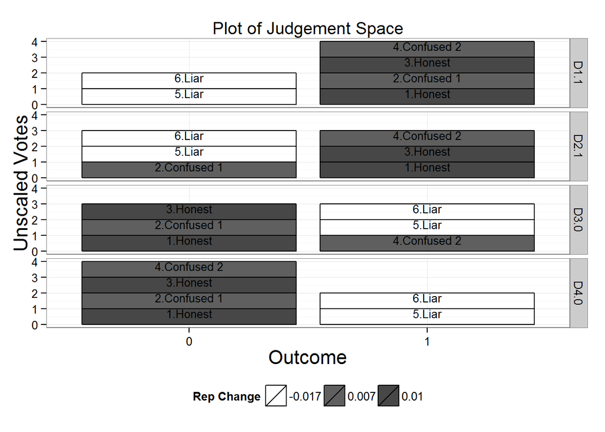

```r
PlotJ(M = Scenarios$Base)
```

Very good. Conforms quickly to a correct prediction. I’m thinking one block per day, or something, assuming we smooth difficulty correctly.

## Reversed

```r
Factory(Scenarios$Reversed)
```

```
## $Original
##            D1.1 D2.1 D3.0 D4.0
## Honest        0    0    1    1
## Confused 1    0    1    1    1
## Honest        0    0    1    1
## Confused 2    0    0    0    1
## Liar          1    1    0    0
## Liar          1    1    0    0
##
## $Filled
##            D1.1 D2.1 D3.0 D4.0
## Honest        0    0    1    1
## Confused 1    0    1    1    1
## Honest        0    0    1    1
## Confused 2    0    0    0    1
## Liar          1    1    0    0
## Liar          1    1    0    0
##
## $Agents
##               OldRep   ThisRep SmoothRep NArow ParticipationR RelativePart
## Honest     0.1666667 0.2673086 0.1767309     0              1    0.1666667
## Confused 1 0.1666667 0.2326914 0.1732691     0              1    0.1666667
## Honest     0.1666667 0.2673086 0.1767309     0              1    0.1666667
## Confused 2 0.1666667 0.2326914 0.1732691     0              1    0.1666667
## Liar       0.1666667 0.0000000 0.1500000     0              1    0.1666667
## Liar       0.1666667 0.0000000 0.1500000     0              1    0.1666667
##             RowBonus
## Honest     0.1767309
## Confused 1 0.1732691
## Honest     0.1767309
## Confused 2 0.1732691
## Liar       0.1500000
## Liar       0.1500000
##
## $Decisions
##                             D1.1       D2.1      D3.0      D4.0
## First Loading         -0.5395366 -0.4570561 0.4570561 0.5395366
## DecisionOutcomes.Raw   0.3000000  0.4732691 0.5267309 0.7000000
## Consensus Reward       0.5000000  0.0000000 0.0000000 0.5000000
## Certainty              0.7000000  0.0000000 0.0000000 0.7000000
## NAs Filled             0.0000000  0.0000000 0.0000000 0.0000000
## ParticipationC         1.0000000  1.0000000 1.0000000 1.0000000
## Author Bonus           0.5000000  0.0000000 0.0000000 0.5000000
## DecisionOutcome.Final  0.0000000  0.5000000 0.5000000 1.0000000
##
## $Participation
## [1] 1
##
## $Certainty
## [1] 0.35
```

```r
all.equal(Factory(Scenarios$Reversed)$Agents,Factory(Scenarios$Base)$Agents) #TRUE
```

```
## [1] TRUE
```

Identical incentive structure, despite reversed inputs and outputs. Good.

## One Liar

```r
Factory(Scenarios$Deviance)
```

```
## $Original
##        D1.1 D2.1 D3.0 D4.0
## Honest    1    1    0    0
## Honest    1    1    0    0
## Honest    1    1    0    0
## Honest    1    1    0    0
## Liar      0    0    1    1
##
## $Filled
##        D1.1 D2.1 D3.0 D4.0
## Honest    1    1    0    0
## Honest    1    1    0    0
## Honest    1    1    0    0
## Honest    1    1    0    0
## Liar      0    0    1    1
##
## $Agents
##        OldRep ThisRep SmoothRep NArow ParticipationR RelativePart RowBonus
## Honest    0.2    0.25     0.205     0              1          0.2    0.205
## Honest    0.2    0.25     0.205     0              1          0.2    0.205
## Honest    0.2    0.25     0.205     0              1          0.2    0.205
## Honest    0.2    0.25     0.205     0              1          0.2    0.205
## Liar      0.2    0.00     0.180     0              1          0.2    0.180
##
## $Decisions
##                        D1.1  D2.1 D3.0 D4.0
## First Loading         -0.50 -0.50 0.50 0.50
## DecisionOutcomes.Raw   0.82  0.82 0.18 0.18
## Consensus Reward       0.25  0.25 0.25 0.25
## Certainty              0.82  0.82 0.82 0.82
## NAs Filled             0.00  0.00 0.00 0.00
## ParticipationC         1.00  1.00 1.00 1.00
## Author Bonus           0.25  0.25 0.25 0.25
## DecisionOutcome.Final  1.00  1.00 0.00 0.00
##
## $Participation
## [1] 1
##
## $Certainty
## [1] 0.82
```

Biggest Deviator gets CRUSHED to zero. High-Stakes! Good.

## Many Liars

```r
Factory(Scenarios$CoalitionalDeviance)
```

```
## $Original
##       [,1] [,2] [,3] [,4]
## True     1    1    0    0
## True     1    1    0    0
## True     1    1    0    0
## True     1    1    0    0
## True     1    1    0    0
## True     1    1    0    0
## Diver    0    0    1    1
## Liar     1    1    1    0
## Liar     1    1    1    0
## Liar     1    1    1    0
## Liar     1    1    1    0
##
## $Filled
##       [,1] [,2] [,3] [,4]
## True     1    1    0    0
## True     1    1    0    0
## True     1    1    0    0
## True     1    1    0    0
## True     1    1    0    0
## True     1    1    0    0
## Diver    0    0    1    1
## Liar     1    1    1    0
## Liar     1    1    1    0
## Liar     1    1    1    0
## Liar     1    1    1    0
##
## $Agents
##           OldRep    ThisRep  SmoothRep NArow ParticipationR RelativePart
## True  0.09090909 0.11715228 0.09353341     0              1   0.09090909
## True  0.09090909 0.11715228 0.09353341     0              1   0.09090909
## True  0.09090909 0.11715228 0.09353341     0              1   0.09090909
## True  0.09090909 0.11715228 0.09353341     0              1   0.09090909
## True  0.09090909 0.11715228 0.09353341     0              1   0.09090909
## True  0.09090909 0.11715228 0.09353341     0              1   0.09090909
## Diver 0.09090909 0.00000000 0.08181818     0              1   0.09090909
## Liar  0.09090909 0.07427157 0.08924534     0              1   0.09090909
## Liar  0.09090909 0.07427157 0.08924534     0              1   0.09090909
## Liar  0.09090909 0.07427157 0.08924534     0              1   0.09090909
```

[output cut: 15 more lines]

```
##                             [,1]       [,2]      [,3]       [,4]
## First Loading         -0.4082483 -0.4082483 0.7071068 0.40824829
## DecisionOutcomes.Raw   0.9181818  0.9181818 0.4387995 0.08181818
## Consensus Reward       0.3333333  0.3333333 0.0000000 0.33333333
## Certainty              0.9181818  0.9181818 0.0000000 0.91818182
## NAs Filled             0.0000000  0.0000000 0.0000000 0.00000000
## ParticipationC         1.0000000  1.0000000 1.0000000 1.00000000
## Author Bonus           0.3333333  0.3333333 0.0000000 0.33333333
## DecisionOutcome.Final  1.0000000  1.0000000 0.5000000 0.00000000
##
## $Participation
## [1] 1
##
## $Certainty
## [1] 0.6886364
```

```r
#Success: An attempted <51% attack which failed.

Factory(Scenarios$CoalitionalDeviance2)
```

```
## $Original
##       [,1] [,2] [,3] [,4]
## True     1    1    0    0
## True     1    1    0    0
## True     1    1    0    0
## True     1    1    0    0
## True     1    1    0    0
## True     1    1    0    0
## Diver    0    0    0    1
## Liar     1    1    1    0
## Liar     1    1    1    0
## Liar     1    1    1    0
## Liar     1    1    1    0
##
## $Filled
##       [,1] [,2] [,3] [,4]
## True     1    1    0    0
## True     1    1    0    0
## True     1    1    0    0
## True     1    1    0    0
## True     1    1    0    0
## True     1    1    0    0
## Diver    0    0    0    1
## Liar     1    1    1    0
## Liar     1    1    1    0
## Liar     1    1    1    0
## Liar     1    1    1    0
##
## $Agents
##           OldRep    ThisRep  SmoothRep NArow ParticipationR RelativePart
## True  0.09090909 0.09090909 0.09090909     0              1   0.09090909
## True  0.09090909 0.09090909 0.09090909     0              1   0.09090909
## True  0.09090909 0.09090909 0.09090909     0              1   0.09090909
## True  0.09090909 0.09090909 0.09090909     0              1   0.09090909
## True  0.09090909 0.09090909 0.09090909     0              1   0.09090909
## True  0.09090909 0.09090909 0.09090909     0              1   0.09090909
## Diver 0.09090909 0.00000000 0.08181818     0              1   0.09090909
## Liar  0.09090909 0.11363636 0.09318182     0              1   0.09090909
## Liar  0.09090909 0.11363636 0.09318182     0              1   0.09090909
## Liar  0.09090909 0.11363636 0.09318182     0              1   0.09090909
```

[output cut: 15 more lines]

```
##                             [,1]       [,2]       [,3]       [,4]
## First Loading         -0.4364358 -0.4364358 -0.6546537 0.43643578
## DecisionOutcomes.Raw   0.9181818  0.9181818  0.3727273 0.08181818
## Consensus Reward       0.2715054  0.2715054  0.1854839 0.27150538
## Certainty              0.9181818  0.9181818  0.6272727 0.91818182
## NAs Filled             0.0000000  0.0000000  0.0000000 0.00000000
## ParticipationC         1.0000000  1.0000000  1.0000000 1.00000000
## Author Bonus           0.2715054  0.2715054  0.1854839 0.27150538
## DecisionOutcome.Final  1.0000000  1.0000000  0.0000000 0.00000000
##
## $Participation
## [1] 1
##
## $Certainty
## [1] 0.8454545
```

```r
# Oh, no: A Sucessful <51% attack 'Friendly Fire' ...will have to address this. [Fixed, in fact it now does something really interesting]

  #Pre-Analytics
  CompareIncentives(X=Scenarios$CoalitionalDeviance2)
```

```
## [[1]]
##    Group     OldRep  SmoothRep         Drep
## 1   True 0.09090909 0.09090909  0.000000000
## 2   True 0.09090909 0.09090909  0.000000000
## 3   True 0.09090909 0.09090909  0.000000000
## 4   True 0.09090909 0.09090909  0.000000000
## 5   True 0.09090909 0.09090909  0.000000000
## 6   True 0.09090909 0.09090909  0.000000000
## 7  Diver 0.09090909 0.08181818 -0.009090909
## 8   Liar 0.09090909 0.09318182  0.002272727
## 9   Liar 0.09090909 0.09318182  0.002272727
## 10  Liar 0.09090909 0.09318182  0.002272727
## 11  Liar 0.09090909 0.09318182  0.002272727
##
## [[2]]
##   Group     OldRep  SmoothRep         Drep
## 2  Liar 0.36363636 0.37272727  0.009090909
## 3  True 0.54545455 0.54545455  0.000000000
## 1 Diver 0.09090909 0.08181818 -0.009090909
```

```r
  row.names( Scenarios$CoalitionalDeviance2 )[7] <- "Liar"
  CompareIncentives(X=Scenarios$CoalitionalDeviance2)
```

```
## [[1]]
##    Group     OldRep  SmoothRep         Drep
## 1   True 0.09090909 0.09090909  0.000000000
## 2   True 0.09090909 0.09090909  0.000000000
## 3   True 0.09090909 0.09090909  0.000000000
## 4   True 0.09090909 0.09090909  0.000000000
## 5   True 0.09090909 0.09090909  0.000000000
## 6   True 0.09090909 0.09090909  0.000000000
## 7   Liar 0.09090909 0.08181818 -0.009090909
## 8   Liar 0.09090909 0.09318182  0.002272727
## 9   Liar 0.09090909 0.09318182  0.002272727
## 10  Liar 0.09090909 0.09318182  0.002272727
## 11  Liar 0.09090909 0.09318182  0.002272727
##
## [[2]]
##   Group    OldRep SmoothRep Drep
## 1  Liar 0.4545455 0.4545455    0
## 2  True 0.5454545 0.5454545    0
```

```r
  # [1] Success: 'Symmetric Friendly Fire'  (ie Team truth forms a coalition of their own)
  Scenarios$CoalitionalDeviance3 <- Scenarios$CoalitionalDeviance2
  Scenarios$CoalitionalDeviance3[6,] <- c(0,0,1,1)

  CompareIncentives(X=Scenarios$CoalitionalDeviance3)
```

```
## [[1]]
##    Group     OldRep  SmoothRep         Drep
## 1   True 0.09090909 0.09297966  0.002070565
## 2   True 0.09090909 0.09297966  0.002070565
## 3   True 0.09090909 0.09297966  0.002070565
## 4   True 0.09090909 0.09297966  0.002070565
## 5   True 0.09090909 0.09297966  0.002070565
## 6   True 0.09090909 0.08181818 -0.009090909
## 7   Liar 0.09090909 0.08227145 -0.008637639
## 8   Liar 0.09090909 0.09275302  0.001843930
## 9   Liar 0.09090909 0.09275302  0.001843930
## 10  Liar 0.09090909 0.09275302  0.001843930
## 11  Liar 0.09090909 0.09275302  0.001843930
##
## [[2]]
##   Group    OldRep SmoothRep         Drep
## 2  True 0.5454545 0.5467165  0.001261918
## 1  Liar 0.4545455 0.4532835 -0.001261918
```

#Chain(Scenarios$CoalitionalDeviance3,N=100) #Team ‘True’ wins via symmetry-exploitation

```r
  # [2] Success: 'Cold Feet 1' (a single player abandons the coalition)
  Scenarios$CoalitionalDeviance4 <- Scenarios$CoalitionalDeviance2
  Scenarios$CoalitionalDeviance4[8,] <- c(1,1,0,0)

  CompareIncentives(X=Scenarios$CoalitionalDeviance4)
```

```
## [[1]]
##    Group     OldRep  SmoothRep          Drep
## 1   True 0.09090909 0.09134199  0.0004329004
## 2   True 0.09090909 0.09134199  0.0004329004
## 3   True 0.09090909 0.09134199  0.0004329004
## 4   True 0.09090909 0.09134199  0.0004329004
## 5   True 0.09090909 0.09134199  0.0004329004
## 6   True 0.09090909 0.09134199  0.0004329004
## 7   Liar 0.09090909 0.08181818 -0.0090909091
## 8   Liar 0.09090909 0.09134199  0.0004329004
## 9   Liar 0.09090909 0.09292929  0.0020202020
## 10  Liar 0.09090909 0.09292929  0.0020202020
## 11  Liar 0.09090909 0.09292929  0.0020202020
##
## [[2]]
##   Group    OldRep SmoothRep         Drep
## 2  True 0.5454545 0.5480519  0.002597403
## 1  Liar 0.4545455 0.4519481 -0.002597403
```

```r
  Ss <- Chain(Scenarios$CoalitionalDeviance4,N=70)[[70]]$Agents
  Ss <- data.frame(NewRep=as.numeric(Ss[,"RowBonus"]),Group=row.names(Ss))
  aggregate(.~Group,data=Ss, FUN=sum)
```

```
##   Group    NewRep
## 1  Liar 0.2425639
## 2  True 0.7574361
```

```r
  Scenarios$CoalitionalDeviance5 <- Scenarios$CoalitionalDeviance2
  Scenarios$CoalitionalDeviance5[8,] <- c(1,1,0,0)
  Scenarios$CoalitionalDeviance5[9,] <- c(1,1,0,0)

  CompareIncentives(X=Scenarios$CoalitionalDeviance5)
```

```
## [[1]]
##    Group     OldRep  SmoothRep          Drep
## 1   True 0.09090909 0.09166584  0.0007567471
## 2   True 0.09090909 0.09166584  0.0007567471
## 3   True 0.09090909 0.09166584  0.0007567471
## 4   True 0.09090909 0.09166584  0.0007567471
## 5   True 0.09090909 0.09166584  0.0007567471
## 6   True 0.09090909 0.09166584  0.0007567471
## 7   Liar 0.09090909 0.08181818 -0.0090909091
## 8   Liar 0.09090909 0.09166584  0.0007567471
## 9   Liar 0.09090909 0.09166584  0.0007567471
## 10  Liar 0.09090909 0.09242756  0.0015184660
## 11  Liar 0.09090909 0.09242756  0.0015184660
##
## [[2]]
##   Group    OldRep SmoothRep         Drep
## 2  True 0.5454545  0.549995  0.004540483
## 1  Liar 0.4545455  0.450005 -0.004540483
```

```r
  Ss <- Chain(Scenarios$CoalitionalDeviance5,N=50)[[50]]$Agents
  Ss <- data.frame(NewRep=as.numeric(Ss[,"RowBonus"]),Group=row.names(Ss))
  aggregate(.~Group,data=Ss, FUN=sum)
```

```
##   Group   NewRep
## 1  Liar 0.319065
## 2  True 0.680935
```

```r
  #Notice after 50 rounds, the devil [=King of Liars] has actually become the two bottommost liars, as they represent the most significant source of confusion.
  #Team 'True' wins via stoicism

  #[3] Recursive Friendly Fire - a sub-coalition forms to defect, but a sub-coalition of this coalition forms to defect again.
  Scenarios$CoalitionalDeviance6 <- rbind(c(1,1,0,0,1),
                                          c(1,1,0,0,1),
                                          c(1,1,0,0,1),
                                          c(1,1,0,0,1),
                                          c(1,1,0,0,1),
                                          c(1,1,0,0,1),
                                          c(1,1,0,0,1),
                                          c(1,1,0,0,1),
                                          c(1,1,0,0,1),
                                          c(1,1,0,0,1), #10
                                          c(1,1,0,0,1),
                                          c(1,1,0,0,1),
                                          c(1,1,0,0,1),
                                          c(1,1,0,0,1),
                                          c(1,1,0,0,1), #15 (60%)

                                          #Coalition 1, backstabbing Truth to game contract 3
                                          c(0,0,0,1,0), #1 - Friendly Fire
                                          c(1,1,1,0,1),
                                          c(1,1,1,0,1),
                                          c(1,1,1,0,1),
                                          c(1,1,1,0,1),
                                          c(1,1,1,0,1), #6 (24%)

                                          #Coalition 2, 'backstabbing' Coalition 1 to game contract 4
                                          c(0,0,1,0,0), #1 - Friendly Fire
                                          c(1,1,0,1,1),
                                          c(1,1,0,1,1),
                                          c(1,1,0,1,1)) #4 (16%)

  row.names(Scenarios$CoalitionalDeviance6) <- c(rep('Truth',15),rep('Lie 1',6),rep('Lie 2',4))
  colnames(Scenarios$CoalitionalDeviance6) <- c("C1.1","C2.1","C3.0","C4.0","C5.1")
  Factory(Scenarios$CoalitionalDeviance6)
```

```
## $Original
##       C1.1 C2.1 C3.0 C4.0 C5.1
## Truth    1    1    0    0    1
## Truth    1    1    0    0    1
## Truth    1    1    0    0    1
## Truth    1    1    0    0    1
## Truth    1    1    0    0    1
## Truth    1    1    0    0    1
## Truth    1    1    0    0    1
## Truth    1    1    0    0    1
## Truth    1    1    0    0    1
## Truth    1    1    0    0    1
## Truth    1    1    0    0    1
## Truth    1    1    0    0    1
## Truth    1    1    0    0    1
## Truth    1    1    0    0    1
## Truth    1    1    0    0    1
## Lie 1    0    0    0    1    0
## Lie 1    1    1    1    0    1
## Lie 1    1    1    1    0    1
## Lie 1    1    1    1    0    1
## Lie 1    1    1    1    0    1
## Lie 1    1    1    1    0    1
## Lie 2    0    0    1    0    0
## Lie 2    1    1    0    1    1
## Lie 2    1    1    0    1    1
## Lie 2    1    1    0    1    1
##
## $Filled
##       C1.1 C2.1 C3.0 C4.0 C5.1
## Truth    1    1    0    0    1
## Truth    1    1    0    0    1
## Truth    1    1    0    0    1
## Truth    1    1    0    0    1
## Truth    1    1    0    0    1
## Truth    1    1    0    0    1
## Truth    1    1    0    0    1
## Truth    1    1    0    0    1
## Truth    1    1    0    0    1
## Truth    1    1    0    0    1
```

[output cut: 71 more lines]

```
##                             C1.1       C2.1      C3.0      C4.0       C5.1
## First Loading         -0.5211237 -0.5211237 0.3447437 0.2577635 -0.5211237
## DecisionOutcomes.Raw   0.9277903  0.9277903 0.2348464 0.1561467  0.9277903
## Consensus Reward       0.2112273  0.2112273 0.1742003 0.1921177  0.2112273
## Certainty              0.9277903  0.9277903 0.7651536 0.8438533  0.9277903
## NAs Filled             0.0000000  0.0000000 0.0000000 0.0000000  0.0000000
## ParticipationC         1.0000000  1.0000000 1.0000000 1.0000000  1.0000000
## Author Bonus           0.2112273  0.2112273 0.1742003 0.1921177  0.2112273
## DecisionOutcome.Final  1.0000000  1.0000000 0.0000000 0.0000000  1.0000000
##
## $Participation
## [1] 1
##
## $Certainty
## [1] 0.8784756
```

```r
  CompareIncentives(Scenarios$CoalitionalDeviance6)
```

```
## [[1]]
##    Group OldRep  SmoothRep          Drep
## 1  Truth   0.04 0.04060046  6.004597e-04
## 2  Truth   0.04 0.04060046  6.004597e-04
## 3  Truth   0.04 0.04060046  6.004597e-04
## 4  Truth   0.04 0.04060046  6.004597e-04
## 5  Truth   0.04 0.04060046  6.004597e-04
## 6  Truth   0.04 0.04060046  6.004597e-04
## 7  Truth   0.04 0.04060046  6.004597e-04
## 8  Truth   0.04 0.04060046  6.004597e-04
## 9  Truth   0.04 0.04060046  6.004597e-04
## 10 Truth   0.04 0.04060046  6.004597e-04
## 11 Truth   0.04 0.04060046  6.004597e-04
## 12 Truth   0.04 0.04060046  6.004597e-04
## 13 Truth   0.04 0.04060046  6.004597e-04
```

[output cut: 18 more lines]

```r
  #fantastic sucess...Lie 2 loses less

  #clearly, the Nash Equilibrium
  Scenarios$CoalitionalDeviance7 <- Scenarios$CoalitionalDeviance6[1:21,]
  Scenarios$CoalitionalDeviance7 <- rbind(Scenarios$CoalitionalDeviance7, rbind(
                                                                              'Truth 2'=c(1,1,0,0,1),
                                                                              'Truth 2'=c(1,1,0,0,1),
                                                                              'Truth 2'=c(1,1,0,0,1),
                                                                              'Truth 2'=c(1,1,0,0,1)))
  Factory(Scenarios$CoalitionalDeviance7)
```

```
## $Original
##         C1.1 C2.1 C3.0 C4.0 C5.1
## Truth      1    1    0    0    1
## Truth      1    1    0    0    1
## Truth      1    1    0    0    1
## Truth      1    1    0    0    1
## Truth      1    1    0    0    1
## Truth      1    1    0    0    1
## Truth      1    1    0    0    1
## Truth      1    1    0    0    1
## Truth      1    1    0    0    1
## Truth      1    1    0    0    1
## Truth      1    1    0    0    1
## Truth      1    1    0    0    1
## Truth      1    1    0    0    1
## Truth      1    1    0    0    1
## Truth      1    1    0    0    1
## Lie 1      0    0    0    1    0
## Lie 1      1    1    1    0    1
## Lie 1      1    1    1    0    1
## Lie 1      1    1    1    0    1
## Lie 1      1    1    1    0    1
## Lie 1      1    1    1    0    1
## Truth 2    1    1    0    0    1
## Truth 2    1    1    0    0    1
## Truth 2    1    1    0    0    1
## Truth 2    1    1    0    0    1
##
## $Filled
##         C1.1 C2.1 C3.0 C4.0 C5.1
## Truth      1    1    0    0    1
## Truth      1    1    0    0    1
## Truth      1    1    0    0    1
## Truth      1    1    0    0    1
## Truth      1    1    0    0    1
## Truth      1    1    0    0    1
## Truth      1    1    0    0    1
## Truth      1    1    0    0    1
## Truth      1    1    0    0    1
## Truth      1    1    0    0    1
```

[output cut: 80 more lines]

```
##                             C5.1
## First Loading         -0.3169945
## DecisionOutcomes.Raw   0.9640000
## Consensus Reward       0.2072923
## Certainty              0.9640000
## NAs Filled             0.0000000
## ParticipationC         1.0000000
## Author Bonus           0.2072923
## DecisionOutcome.Final  1.0000000
##
## $Participation
## [1] 1
##
## $Certainty
## [1] 0.9300875
```

```r
  CompareIncentives(Scenarios$CoalitionalDeviance7)
```

```
## [[1]]
##      Group OldRep  SmoothRep          Drep
## 1    Truth   0.04 0.03991777 -8.223466e-05
## 2    Truth   0.04 0.03991777 -8.223466e-05
## 3    Truth   0.04 0.03991777 -8.223466e-05
## 4    Truth   0.04 0.03991777 -8.223466e-05
## 5    Truth   0.04 0.03991777 -8.223466e-05
## 6    Truth   0.04 0.03991777 -8.223466e-05
## 7    Truth   0.04 0.03991777 -8.223466e-05
## 8    Truth   0.04 0.03991777 -8.223466e-05
## 9    Truth   0.04 0.03991777 -8.223466e-05
## 10   Truth   0.04 0.03991777 -8.223466e-05
## 11   Truth   0.04 0.03991777 -8.223466e-05
## 12   Truth   0.04 0.03991777 -8.223466e-05
## 13   Truth   0.04 0.03991777 -8.223466e-05
```

[output cut: 18 more lines]

```r
  # [4] Passive - Sideways expansion by 2 contracts
  Scenarios$CoalitionalDeviance8 <- cbind(Scenarios$CoalitionalDeviance2,Scenarios$CoalitionalDeviance2[,1:2])
  Factory(Scenarios$CoalitionalDeviance8)
```

```
## $Original
##      [,1] [,2] [,3] [,4] [,5] [,6]
## True    1    1    0    0    1    1
## True    1    1    0    0    1    1
## True    1    1    0    0    1    1
## True    1    1    0    0    1    1
## True    1    1    0    0    1    1
## True    1    1    0    0    1    1
## Liar    0    0    0    1    0    0
## Liar    1    1    1    0    1    1
## Liar    1    1    1    0    1    1
## Liar    1    1    1    0    1    1
## Liar    1    1    1    0    1    1
##
## $Filled
##      [,1] [,2] [,3] [,4] [,5] [,6]
## True    1    1    0    0    1    1
## True    1    1    0    0    1    1
## True    1    1    0    0    1    1
## True    1    1    0    0    1    1
## True    1    1    0    0    1    1
## True    1    1    0    0    1    1
## Liar    0    0    0    1    0    0
## Liar    1    1    1    0    1    1
## Liar    1    1    1    0    1    1
## Liar    1    1    1    0    1    1
## Liar    1    1    1    0    1    1
##
## $Agents
##          OldRep    ThisRep  SmoothRep NArow ParticipationR RelativePart
## True 0.09090909 0.09692041 0.09151022     0              1   0.09090909
## True 0.09090909 0.09692041 0.09151022     0              1   0.09090909
## True 0.09090909 0.09692041 0.09151022     0              1   0.09090909
## True 0.09090909 0.09692041 0.09151022     0              1   0.09090909
## True 0.09090909 0.09692041 0.09151022     0              1   0.09090909
## True 0.09090909 0.09692041 0.09151022     0              1   0.09090909
## Liar 0.09090909 0.00000000 0.08181818     0              1   0.09090909
## Liar 0.09090909 0.10461939 0.09228012     0              1   0.09090909
## Liar 0.09090909 0.10461939 0.09228012     0              1   0.09090909
## Liar 0.09090909 0.10461939 0.09228012     0              1   0.09090909
```

[output cut: 24 more lines]

```
##                             [,5]       [,6]
## First Loading         -0.4214119 -0.4214119
## DecisionOutcomes.Raw   0.9181818  0.9181818
## Consensus Reward       0.1758367  0.1758367
## Certainty              0.9181818  0.9181818
## NAs Filled             0.0000000  0.0000000
## ParticipationC         1.0000000  1.0000000
## Author Bonus           0.1758367  0.1758367
## DecisionOutcome.Final  1.0000000  1.0000000
##
## $Participation
## [1] 1
##
## $Certainty
## [1] 0.8702981
```

```r
  CompareIncentives(Scenarios$CoalitionalDeviance8)
```

```
## [[1]]
##    Group     OldRep  SmoothRep          Drep
## 1   True 0.09090909 0.09151022  0.0006011315
## 2   True 0.09090909 0.09151022  0.0006011315
## 3   True 0.09090909 0.09151022  0.0006011315
## 4   True 0.09090909 0.09151022  0.0006011315
## 5   True 0.09090909 0.09151022  0.0006011315
## 6   True 0.09090909 0.09151022  0.0006011315
## 7   Liar 0.09090909 0.08181818 -0.0090909091
## 8   Liar 0.09090909 0.09228012  0.0013710301
## 9   Liar 0.09090909 0.09228012  0.0013710301
## 10  Liar 0.09090909 0.09228012  0.0013710301
## 11  Liar 0.09090909 0.09228012  0.0013710301
##
## [[2]]
##   Group    OldRep SmoothRep         Drep
## 2  True 0.5454545 0.5490613  0.003606789
## 1  Liar 0.4545455 0.4509387 -0.003606789
```

```r
  #Success, larger number of contracts makes this attack improbable.

  Scenarios$CoalitionalDeviance9 <- cbind(Scenarios$CoalitionalDeviance2,
                                          Scenarios$CoalitionalDeviance2,
                                          Scenarios$CoalitionalDeviance2,
                                          Scenarios$CoalitionalDeviance2[,-3])
  Factory(Scenarios$CoalitionalDeviance9)
```

```
## $Original
##      [,1] [,2] [,3] [,4] [,5] [,6] [,7] [,8] [,9] [,10] [,11] [,12] [,13]
## True    1    1    0    0    1    1    0    0    1     1     0     0     1
## True    1    1    0    0    1    1    0    0    1     1     0     0     1
## True    1    1    0    0    1    1    0    0    1     1     0     0     1
## True    1    1    0    0    1    1    0    0    1     1     0     0     1
## True    1    1    0    0    1    1    0    0    1     1     0     0     1
## True    1    1    0    0    1    1    0    0    1     1     0     0     1
## Liar    0    0    0    1    0    0    0    1    0     0     0     1     0
## Liar    1    1    1    0    1    1    1    0    1     1     1     0     1
## Liar    1    1    1    0    1    1    1    0    1     1     1     0     1
## Liar    1    1    1    0    1    1    1    0    1     1     1     0     1
## Liar    1    1    1    0    1    1    1    0    1     1     1     0     1
##      [,14] [,15]
## True     1     0
## True     1     0
## True     1     0
## True     1     0
## True     1     0
## True     1     0
## Liar     0     1
## Liar     1     0
## Liar     1     0
## Liar     1     0
## Liar     1     0
##
## $Filled
##      [,1] [,2] [,3] [,4] [,5] [,6] [,7] [,8] [,9] [,10] [,11] [,12] [,13]
## True    1    1    0    0    1    1    0    0    1     1     0     0     1
## True    1    1    0    0    1    1    0    0    1     1     0     0     1
## True    1    1    0    0    1    1    0    0    1     1     0     0     1
## True    1    1    0    0    1    1    0    0    1     1     0     0     1
## True    1    1    0    0    1    1    0    0    1     1     0     0     1
## True    1    1    0    0    1    1    0    0    1     1     0     0     1
## Liar    0    0    0    1    0    0    0    1    0     0     0     1     0
## Liar    1    1    1    0    1    1    1    0    1     1     1     0     1
## Liar    1    1    1    0    1    1    1    0    1     1     1     0     1
## Liar    1    1    1    0    1    1    1    0    1     1     1     0     1
## Liar    1    1    1    0    1    1    1    0    1     1     1     0     1
##      [,14] [,15]
```

[output cut: 66 more lines]

```
##                             [,13]       [,14]      [,15]
## First Loading         -0.25819889 -0.25819889 0.25819889
## DecisionOutcomes.Raw   0.91818182  0.91818182 0.08181818
## Consensus Reward       0.07113392  0.07113392 0.07113392
## Certainty              0.91818182  0.91818182 0.91818182
## NAs Filled             0.00000000  0.00000000 0.00000000
## ParticipationC         1.00000000  1.00000000 1.00000000
## Author Bonus           0.07113392  0.07113392 0.07113392
## DecisionOutcome.Final  1.00000000  1.00000000 0.00000000
##
## $Participation
## [1] 1
##
## $Certainty
## [1] 0.8605195
```

```r
  CompareIncentives(Scenarios$CoalitionalDeviance9)
```

```
## [[1]]
##    Group     OldRep  SmoothRep          Drep
## 1   True 0.09090909 0.09134199  0.0004329004
## 2   True 0.09090909 0.09134199  0.0004329004
## 3   True 0.09090909 0.09134199  0.0004329004
## 4   True 0.09090909 0.09134199  0.0004329004
## 5   True 0.09090909 0.09134199  0.0004329004
## 6   True 0.09090909 0.09134199  0.0004329004
## 7   Liar 0.09090909 0.08181818 -0.0090909091
## 8   Liar 0.09090909 0.09253247  0.0016233766
## 9   Liar 0.09090909 0.09253247  0.0016233766
## 10  Liar 0.09090909 0.09253247  0.0016233766
## 11  Liar 0.09090909 0.09253247  0.0016233766
##
## [[2]]
##   Group    OldRep SmoothRep         Drep
## 2  True 0.5454545 0.5480519  0.002597403
## 1  Liar 0.4545455 0.4519481 -0.002597403
```

```r
  #The attack must expand proportionally.

  Scenarios$CoalitionalDeviance10 <- cbind(Scenarios$CoalitionalDeviance2,
                                           Scenarios$CoalitionalDeviance2,
                                           Scenarios$CoalitionalDeviance2,
                                           Scenarios$CoalitionalDeviance2)
  Factory(Scenarios$CoalitionalDeviance10)
```

```
## $Original
##      [,1] [,2] [,3] [,4] [,5] [,6] [,7] [,8] [,9] [,10] [,11] [,12] [,13]
## True    1    1    0    0    1    1    0    0    1     1     0     0     1
## True    1    1    0    0    1    1    0    0    1     1     0     0     1
## True    1    1    0    0    1    1    0    0    1     1     0     0     1
## True    1    1    0    0    1    1    0    0    1     1     0     0     1
## True    1    1    0    0    1    1    0    0    1     1     0     0     1
## True    1    1    0    0    1    1    0    0    1     1     0     0     1
## Liar    0    0    0    1    0    0    0    1    0     0     0     1     0
## Liar    1    1    1    0    1    1    1    0    1     1     1     0     1
## Liar    1    1    1    0    1    1    1    0    1     1     1     0     1
## Liar    1    1    1    0    1    1    1    0    1     1     1     0     1
## Liar    1    1    1    0    1    1    1    0    1     1     1     0     1
##      [,14] [,15] [,16]
## True     1     0     0
## True     1     0     0
## True     1     0     0
## True     1     0     0
## True     1     0     0
## True     1     0     0
## Liar     0     0     1
## Liar     1     1     0
## Liar     1     1     0
## Liar     1     1     0
## Liar     1     1     0
##
## $Filled
##      [,1] [,2] [,3] [,4] [,5] [,6] [,7] [,8] [,9] [,10] [,11] [,12] [,13]
## True    1    1    0    0    1    1    0    0    1     1     0     0     1
## True    1    1    0    0    1    1    0    0    1     1     0     0     1
## True    1    1    0    0    1    1    0    0    1     1     0     0     1
## True    1    1    0    0    1    1    0    0    1     1     0     0     1
## True    1    1    0    0    1    1    0    0    1     1     0     0     1
## True    1    1    0    0    1    1    0    0    1     1     0     0     1
## Liar    0    0    0    1    0    0    0    1    0     0     0     1     0
## Liar    1    1    1    0    1    1    1    0    1     1     1     0     1
## Liar    1    1    1    0    1    1    1    0    1     1     1     0     1
## Liar    1    1    1    0    1    1    1    0    1     1     1     0     1
## Liar    1    1    1    0    1    1    1    0    1     1     1     0     1
##      [,14] [,15] [,16]
```

[output cut: 66 more lines]

```
##                             [,13]       [,14]       [,15]      [,16]
## First Loading         -0.21821789 -0.21821789 -0.32732684 0.21821789
## DecisionOutcomes.Raw   0.91818182  0.91818182  0.37272727 0.08181818
## Consensus Reward       0.06787634  0.06787634  0.04637097 0.06787634
## Certainty              0.91818182  0.91818182  0.62727273 0.91818182
## NAs Filled             0.00000000  0.00000000  0.00000000 0.00000000
## ParticipationC         1.00000000  1.00000000  1.00000000 1.00000000
## Author Bonus           0.06787634  0.06787634  0.04637097 0.06787634
## DecisionOutcome.Final  1.00000000  1.00000000  0.00000000 0.00000000
##
## $Participation
## [1] 1
##
## $Certainty
## [1] 0.8454545
```

```r
  CompareIncentives(Scenarios$CoalitionalDeviance10)
```

```
## [[1]]
##    Group     OldRep  SmoothRep         Drep
## 1   True 0.09090909 0.09090909  0.000000000
## 2   True 0.09090909 0.09090909  0.000000000
## 3   True 0.09090909 0.09090909  0.000000000
## 4   True 0.09090909 0.09090909  0.000000000
## 5   True 0.09090909 0.09090909  0.000000000
## 6   True 0.09090909 0.09090909  0.000000000
## 7   Liar 0.09090909 0.08181818 -0.009090909
## 8   Liar 0.09090909 0.09318182  0.002272727
## 9   Liar 0.09090909 0.09318182  0.002272727
## 10  Liar 0.09090909 0.09318182  0.002272727
## 11  Liar 0.09090909 0.09318182  0.002272727
##
## [[2]]
##   Group    OldRep SmoothRep Drep
## 1  Liar 0.4545455 0.4545455    0
## 2  True 0.5454545 0.5454545    0
```

```r
  #The attack must expand proportionally.
```

## Uninformed People

```r
Factory(Scenarios$CluelessControl)
```

```
## $Original
##      D1.1 D2.1 D3.0 D4.0
## True    1    1    0    0
## True    1    1    0    0
## True    1    1    0    0
## True    1    1    0    0
## True    1    1    0    0
## True    1    1    0    0
## True    1    1    0    0
##
## $Filled
##      D1.1 D2.1 D3.0 D4.0
## True    1    1    0    0
## True    1    1    0    0
## True    1    1    0    0
## True    1    1    0    0
## True    1    1    0    0
## True    1    1    0    0
## True    1    1    0    0
##
## $Agents
##         OldRep   ThisRep SmoothRep NArow ParticipationR RelativePart
## True 0.1428571 0.1428571 0.1428571     0              1    0.1428571
## True 0.1428571 0.1428571 0.1428571     0              1    0.1428571
## True 0.1428571 0.1428571 0.1428571     0              1    0.1428571
## True 0.1428571 0.1428571 0.1428571     0              1    0.1428571
## True 0.1428571 0.1428571 0.1428571     0              1    0.1428571
## True 0.1428571 0.1428571 0.1428571     0              1    0.1428571
## True 0.1428571 0.1428571 0.1428571     0              1    0.1428571
##       RowBonus
## True 0.1428571
## True 0.1428571
## True 0.1428571
## True 0.1428571
## True 0.1428571
## True 0.1428571
## True 0.1428571
##
## $Decisions
##                       D1.1 D2.1 D3.0 D4.0
## First Loading         1.00 0.00 0.00 0.00
## DecisionOutcomes.Raw  1.00 1.00 0.00 0.00
## Consensus Reward      0.25 0.25 0.25 0.25
## Certainty             1.00 1.00 1.00 1.00
## NAs Filled            0.00 0.00 0.00 0.00
## ParticipationC        1.00 1.00 1.00 1.00
## Author Bonus          0.25 0.25 0.25 0.25
## DecisionOutcome.Final 1.00 1.00 0.00 0.00
##
## $Participation
## [1] 1
##
## $Certainty
## [1] 1
```

```r
Factory(Scenarios$CluelessTest)
```

```
## $Original
##      D1.1 D2.1 D3.0 D4.0
## True    1    1    0    0
## True    1   NA    0    0
## True    1    1    0    0
## True    1    1    0    0
## True    1    1    0    0
## True    1    1    0    0
## True    1    1    0    0
##
## $Filled
##      D1.1 D2.1 D3.0 D4.0
## True    1    1    0    0
## True    1    1    0    0
## True    1    1    0    0
## True    1    1    0    0
## True    1    1    0    0
## True    1    1    0    0
## True    1    1    0    0
##
## $Agents
##         OldRep   ThisRep SmoothRep NArow ParticipationR RelativePart
## True 0.1428571 0.1428571 0.1428571     0           1.00    0.1481481
## True 0.1428571 0.1428571 0.1428571     1           0.75    0.1111111
## True 0.1428571 0.1428571 0.1428571     0           1.00    0.1481481
## True 0.1428571 0.1428571 0.1428571     0           1.00    0.1481481
## True 0.1428571 0.1428571 0.1428571     0           1.00    0.1481481
## True 0.1428571 0.1428571 0.1428571     0           1.00    0.1481481
## True 0.1428571 0.1428571 0.1428571     0           1.00    0.1481481
##       RowBonus
## True 0.1430461
## True 0.1417234
## True 0.1430461
## True 0.1430461
## True 0.1430461
## True 0.1430461
## True 0.1430461
##
## $Decisions
##                            D1.1      D2.1      D3.0      D4.0
## First Loading         1.0000000 0.0000000 0.0000000 0.0000000
## DecisionOutcomes.Raw  1.0000000 1.0000000 0.0000000 0.0000000
## Consensus Reward      0.2500000 0.2500000 0.2500000 0.2500000
## Certainty             1.0000000 1.0000000 1.0000000 1.0000000
## NAs Filled            0.0000000 1.0000000 0.0000000 0.0000000
## ParticipationC        1.0000000 0.8571429 1.0000000 1.0000000
## Author Bonus          0.2503307 0.2490079 0.2503307 0.2503307
## DecisionOutcome.Final 1.0000000 1.0000000 0.0000000 0.0000000
##
## $Participation
## [1] 0.9642857
##
## $Certainty
## [1] 1
```

Finding: 2 falls from tie at 5th .11 to a tie at 7th with .07; no impact on other results: success.

[done] Note: Must be a discrete set of options: c(1,0,NA,.5) —- !!! by extention, Catch must be implemented in FillNA. Indeed, in this example our lazy character is punished twice. otherwise there will likely be pragmatic individuals who rationally deviate to answers like ~.85 or ~.92 or some nonsense. [obviously]

## Overwhelming Incoherence

```r
Factory(Scenarios$Incoherence)
```

```
## $Original
##               D1.1 D2.(.5) D3.0 D4.0
## True             1     0.5    0    0
## True             1     0.5    0    0
## Overconfident    1     1.0    0    0
## True             1     0.5    0    0
## True             1     0.5    0    0
## True             1     0.5    0    0
## True             1     0.5    0    0
##
## $Filled
##               D1.1 D2.(.5) D3.0 D4.0
## True             1     0.5    0    0
## True             1     0.5    0    0
## Overconfident    1     1.0    0    0
## True             1     0.5    0    0
## True             1     0.5    0    0
## True             1     0.5    0    0
## True             1     0.5    0    0
##
## $Agents
##                  OldRep   ThisRep SmoothRep NArow ParticipationR
## True          0.1428571 0.1666667 0.1452381     0              1
## True          0.1428571 0.1666667 0.1452381     0              1
## Overconfident 0.1428571 0.0000000 0.1285714     0              1
## True          0.1428571 0.1666667 0.1452381     0              1
## True          0.1428571 0.1666667 0.1452381     0              1
## True          0.1428571 0.1666667 0.1452381     0              1
## True          0.1428571 0.1666667 0.1452381     0              1
##               RelativePart  RowBonus
## True             0.1428571 0.1452381
## True             0.1428571 0.1452381
## Overconfident    0.1428571 0.1285714
## True             0.1428571 0.1452381
## True             0.1428571 0.1452381
## True             0.1428571 0.1452381
## True             0.1428571 0.1452381
##
## $Decisions
##                            D1.1    D2.(.5)      D3.0      D4.0
## First Loading         0.0000000 1.00000000 0.0000000 0.0000000
## DecisionOutcomes.Raw  1.0000000 0.56428571 0.0000000 0.0000000
## Consensus Reward      0.3200523 0.03984324 0.3200523 0.3200523
## Certainty             1.0000000 0.87142857 1.0000000 1.0000000
## NAs Filled            0.0000000 0.00000000 0.0000000 0.0000000
## ParticipationC        1.0000000 1.00000000 1.0000000 1.0000000
## Author Bonus          0.3200523 0.03984324 0.3200523 0.3200523
## DecisionOutcome.Final 1.0000000 0.50000000 0.0000000 0.0000000
##
## $Participation
## [1] 1
##
## $Certainty
## [1] 0.9678571
```

```r
Factory(Scenarios$Incoherence2)
```

```
## $Original
##               D1.1 D2.(.5) D3.0 D4.0
## True             1     0.5    0    0
## True             1     0.5    0    0
## Overconfident    1     1.0    0    0
## True             1     0.5    0    0
## True             1     0.5    0    0
## True             1     0.5    0    0
## True             1     0.0    0    0
##
## $Filled
##               D1.1 D2.(.5) D3.0 D4.0
## True             1     0.5    0    0
## True             1     0.5    0    0
## Overconfident    1     1.0    0    0
## True             1     0.5    0    0
## True             1     0.5    0    0
## True             1     0.5    0    0
## True             1     0.0    0    0
##
## $Agents
##                  OldRep   ThisRep SmoothRep NArow ParticipationR
## True          0.1428571 0.1538462 0.1439560     0              1
## True          0.1428571 0.1538462 0.1439560     0              1
## Overconfident 0.1428571 0.0000000 0.1285714     0              1
## True          0.1428571 0.1538462 0.1439560     0              1
## True          0.1428571 0.1538462 0.1439560     0              1
## True          0.1428571 0.1538462 0.1439560     0              1
## True          0.1428571 0.2307692 0.1516484     0              1
##               RelativePart  RowBonus
## True             0.1428571 0.1439560
## True             0.1428571 0.1439560
## Overconfident    0.1428571 0.1285714
## True             0.1428571 0.1439560
## True             0.1428571 0.1439560
## True             0.1428571 0.1439560
## True             0.1428571 0.1516484
##
## $Decisions
##                            D1.1    D2.(.5)      D3.0      D4.0
## First Loading         0.0000000 1.00000000 0.0000000 0.0000000
## DecisionOutcomes.Raw  1.0000000 0.48846154 0.0000000 0.0000000
## Consensus Reward      0.3119491 0.06415279 0.3119491 0.3119491
## Certainty             1.0000000 0.71978022 1.0000000 1.0000000
## NAs Filled            0.0000000 0.00000000 0.0000000 0.0000000
## ParticipationC        1.0000000 1.00000000 1.0000000 1.0000000
## Author Bonus          0.3119491 0.06415279 0.3119491 0.3119491
## DecisionOutcome.Final 1.0000000 0.50000000 0.0000000 0.0000000
##
## $Participation
## [1] 1
##
## $Certainty
## [1] 0.9299451
```

Interesting behavior, but incentive compatible, particularly given low Schelling Salience Incentive to switch to the consensus .5

## Perfect Consensus

```r
Factory(Scenarios$PerCon)
```

```
## $Original
##      D1.1 D2.1 D3.0 D4.0
## [1,]    1    1    0    0
## [2,]    1    1    0    0
## [3,]    1    1    0    0
## [4,]    1    1    0    0
##
## $Filled
##      D1.1 D2.1 D3.0 D4.0
## [1,]    1    1    0    0
## [2,]    1    1    0    0
## [3,]    1    1    0    0
## [4,]    1    1    0    0
##
## $Agents
##      OldRep ThisRep SmoothRep NArow ParticipationR RelativePart RowBonus
## [1,]   0.25    0.25      0.25     0              1         0.25     0.25
## [2,]   0.25    0.25      0.25     0              1         0.25     0.25
## [3,]   0.25    0.25      0.25     0              1         0.25     0.25
## [4,]   0.25    0.25      0.25     0              1         0.25     0.25
##
## $Decisions
##                       D1.1 D2.1 D3.0 D4.0
## First Loading         1.00 0.00 0.00 0.00
## DecisionOutcomes.Raw  1.00 1.00 0.00 0.00
## Consensus Reward      0.25 0.25 0.25 0.25
## Certainty             1.00 1.00 1.00 1.00
## NAs Filled            0.00 0.00 0.00 0.00
## ParticipationC        1.00 1.00 1.00 1.00
## Author Bonus          0.25 0.25 0.25 0.25
## DecisionOutcome.Final 1.00 1.00 0.00 0.00
##
## $Participation
## [1] 1
##
## $Certainty
## [1] 1
```

```r
#No problems.
```

## Gaming

```r
Factory(Scenarios$Gaming)
```

```
## $Original
##            D1.1 D2.1 D3.0 D4.0 C0.5 C0.5 C0.5 C0.5 C0.5 C0.5 C0.5 C0.5
## Honest        1    1    0    0  0.5  0.5  0.5  0.5  0.5  0.5  0.5  0.5
## Confused 1    1    0    0    0  0.5  0.5  0.5  0.5  0.5  0.5  0.5  0.5
## Honest        1    1    0    0  0.5  0.5  0.5  0.5  0.5  0.5  0.5  0.5
## Confused 2    1    1    1    0  0.5  0.5  0.5  0.5  0.5  0.5  0.5  0.5
## Liar          0    0    1    1  0.0  1.0  0.0  1.0  0.0  1.0  0.0  1.0
## Liar          0    0    1    1  1.0  0.0  1.0  0.0  1.0  0.0  1.0  0.0
## Honest        1    1    0    0  0.5  0.5  0.5  0.5  0.5  0.5  0.5  0.5
## Confused 1    1    0    0    0  0.5  0.5  0.5  0.5  0.5  0.5  0.5  0.5
## Honest        1    1    0    0  0.5  0.5  0.5  0.5  0.5  0.5  0.5  0.5
## Confused 2    1    1    1    0  0.5  0.5  0.5  0.5  0.5  0.5  0.5  0.5
## Liar          0    0    1    1  0.0  1.0  0.0  1.0  0.0  1.0  0.0  1.0
## Liar          0    0    1    1  1.0  0.0  1.0  0.0  1.0  0.0  1.0  0.0
## Honest        1    1    0    0  0.5  0.5  0.5  0.5  0.5  0.5  0.5  0.5
## Confused 1    1    0    0    0  0.5  0.5  0.5  0.5  0.5  0.5  0.5  0.5
## Honest        1    1    0    0  0.5  0.5  0.5  0.5  0.5  0.5  0.5  0.5
## Confused 2    1    1    1    0  0.5  0.5  0.5  0.5  0.5  0.5  0.5  0.5
## Liar          0    0    1    1  0.0  1.0  0.0  1.0  0.0  1.0  0.0  1.0
## Liar          0    0    1    1  1.0  0.0  1.0  0.0  1.0  0.0  1.0  0.0
## Honest        1    1    0    0  0.5  0.5  0.5  0.5  0.5  0.5  0.5  0.5
## Confused 1    1    0    0    0  0.5  0.5  0.5  0.5  0.5  0.5  0.5  0.5
## Honest        1    1    0    0  0.5  0.5  0.5  0.5  0.5  0.5  0.5  0.5
## Confused 2    1    1    1    0  0.5  0.5  0.5  0.5  0.5  0.5  0.5  0.5
## Liar          0    0    1    1  0.0  1.0  0.0  1.0  0.0  1.0  0.0  1.0
## Liar          0    0    1    1  1.0  0.0  1.0  0.0  1.0  0.0  1.0  0.0
##
## $Filled
##            D1.1 D2.1 D3.0 D4.0 C0.5 C0.5 C0.5 C0.5 C0.5 C0.5 C0.5 C0.5
## Honest        1    1    0    0  0.5  0.5  0.5  0.5  0.5  0.5  0.5  0.5
## Confused 1    1    0    0    0  0.5  0.5  0.5  0.5  0.5  0.5  0.5  0.5
## Honest        1    1    0    0  0.5  0.5  0.5  0.5  0.5  0.5  0.5  0.5
## Confused 2    1    1    1    0  0.5  0.5  0.5  0.5  0.5  0.5  0.5  0.5
## Liar          0    0    1    1  0.0  1.0  0.0  1.0  0.0  1.0  0.0  1.0
## Liar          0    0    1    1  1.0  0.0  1.0  0.0  1.0  0.0  1.0  0.0
## Honest        1    1    0    0  0.5  0.5  0.5  0.5  0.5  0.5  0.5  0.5
## Confused 1    1    0    0    0  0.5  0.5  0.5  0.5  0.5  0.5  0.5  0.5
## Honest        1    1    0    0  0.5  0.5  0.5  0.5  0.5  0.5  0.5  0.5
## Confused 2    1    1    1    0  0.5  0.5  0.5  0.5  0.5  0.5  0.5  0.5
## Liar          0    0    1    1  0.0  1.0  0.0  1.0  0.0  1.0  0.0  1.0
```

[output cut: 85 more lines]

```
##                             C0.5       C0.5       C0.5
## First Loading         0.00000000 0.00000000 0.00000000
## DecisionOutcomes.Raw  0.50000000 0.50000000 0.50000000
## Consensus Reward      0.07142857 0.07142857 0.07142857
## Certainty             0.70000000 0.70000000 0.70000000
## NAs Filled            0.00000000 0.00000000 0.00000000
## ParticipationC        1.00000000 1.00000000 1.00000000
## Author Bonus          0.07142857 0.07142857 0.07142857
## DecisionOutcome.Final 0.50000000 0.50000000 0.50000000
##
## $Participation
## [1] 1
##
## $Certainty
## [1] 0.5833333
```

```r
CompareIncentives(Scenarios$Gaming)
```

```
## [[1]]
##         Group     OldRep  SmoothRep         Drep
## 1      Honest 0.04166667 0.04418272  0.002516048
## 2  Confused 1 0.04166667 0.04331728  0.001650618
## 3      Honest 0.04166667 0.04418272  0.002516048
## 4  Confused 2 0.04166667 0.04331728  0.001650618
## 5        Liar 0.04166667 0.03750000 -0.004166667
## 6        Liar 0.04166667 0.03750000 -0.004166667
## 7      Honest 0.04166667 0.04418272  0.002516048
## 8  Confused 1 0.04166667 0.04331728  0.001650618
## 9      Honest 0.04166667 0.04418272  0.002516048
## 10 Confused 2 0.04166667 0.04331728  0.001650618
## 11       Liar 0.04166667 0.03750000 -0.004166667
## 12       Liar 0.04166667 0.03750000 -0.004166667
## 13     Honest 0.04166667 0.04418272  0.002516048
```

[output cut: 18 more lines]

```r
#more or less what i expected
```

## Missing Values

```r
Factory(Scenarios$Missing1)
```

```
## $Original
##            D1.1 D2.1 D3.0 D4.0 D5.0
## Honest        1    1    0    0    0
## Confused 1    1    0    0    0   NA
## Honest        1    1    0    0    0
## Confused 2    1    1    1    0   NA
## Liar          0    0    1    1    1
## Liar          0    0    1    1    1
##
## $Filled
##            D1.1 D2.1 D3.0 D4.0 D5.0
## Honest        1    1    0    0  0.0
## Confused 1    1    0    0    0  0.5
## Honest        1    1    0    0  0.0
## Confused 2    1    1    1    0  0.5
## Liar          0    0    1    1  1.0
## Liar          0    0    1    1  1.0
##
## $Agents
##               OldRep   ThisRep SmoothRep NArow ParticipationR RelativePart
## Honest     0.1666667 0.2725172 0.1772517     0            1.0    0.1785714
## Confused 1 0.1666667 0.2274828 0.1727483     1            0.8    0.1428571
## Honest     0.1666667 0.2725172 0.1772517     0            1.0    0.1785714
## Confused 2 0.1666667 0.2274828 0.1727483     1            0.8    0.1428571
## Liar       0.1666667 0.0000000 0.1500000     0            1.0    0.1785714
## Liar       0.1666667 0.0000000 0.1500000     0            1.0    0.1785714
##             RowBonus
## Honest     0.1773429
## Confused 1 0.1706828
## Honest     0.1773429
## Confused 2 0.1706828
## Liar       0.1519743
## Liar       0.1519743
##
## $Decisions
##                             D1.1        D2.1       D3.0      D4.0
## First Loading         -0.4827307 -0.42187763 0.42187763 0.4827307
## DecisionOutcomes.Raw   0.7000000  0.52725172 0.47274828 0.3000000
## Consensus Reward       0.4293607  0.00000000 0.00000000 0.4293607
## Certainty              0.7000000  0.00000000 0.00000000 0.7000000
## NAs Filled             0.0000000  0.00000000 0.00000000 0.0000000
## ParticipationC         1.0000000  1.00000000 1.00000000 1.0000000
## Author Bonus           0.4145378  0.01484569 0.01484569 0.4145378
## DecisionOutcome.Final  1.0000000  0.50000000 0.50000000 0.0000000
##                            D5.0
## First Loading         0.4218776
## DecisionOutcomes.Raw  0.4727483
## Consensus Reward      0.1412787
## Certainty             0.3454966
## NAs Filled            2.0000000
## ParticipationC        0.6545034
## Author Bonus          0.1412330
## DecisionOutcome.Final 0.5000000
##
## $Participation
## [1] 0.9309007
##
## $Certainty
## [1] 0.3490993
```

```r
Factory(Scenarios$Missing2)
```

```
## $Original
##            D1.1 D2.1 D3.0 D4.0 D5.0 D6.1 D6.0
## Honest        1    1    0    0    0    1   NA
## Confused 1    1    0    0    0   NA    1   NA
## Honest        1    1    0    0    0    1   NA
## Confused 2    1    1    1    0   NA   NA    0
## Liar          0    0    1    1    1    0    1
## Liar          0    0    1    1    1    0    1
## Honest        1    1    0    0    0    1   NA
## Confused 1    1    0    0    0   NA    1   NA
## Honest        1    1    0    0    0    1   NA
## Confused 2    1    1    1    0   NA   NA    0
## Liar          0    0    1    1    1    0    1
## Liar          0    0    1    1    1    0    1
##
## $Filled
##            D1.1 D2.1 D3.0 D4.0 D5.0 D6.1 D6.0
## Honest        1    1    0    0  0.0  1.0    1
## Confused 1    1    0    0    0  0.5  1.0    1
## Honest        1    1    0    0  0.0  1.0    1
## Confused 2    1    1    1    0  0.5  0.5    0
## Liar          0    0    1    1  1.0  0.0    1
## Liar          0    0    1    1  1.0  0.0    1
## Honest        1    1    0    0  0.0  1.0    1
## Confused 1    1    0    0    0  0.5  1.0    1
## Honest        1    1    0    0  0.0  1.0    1
## Confused 2    1    1    1    0  0.5  0.5    0
## Liar          0    0    1    1  1.0  0.0    1
## Liar          0    0    1    1  1.0  0.0    1
##
## $Agents
##                OldRep   ThisRep  SmoothRep NArow ParticipationR
## Honest     0.08333333 0.1363391 0.08863391     1      0.8571429
## Confused 1 0.08333333 0.1184022 0.08684022     2      0.7142857
## Honest     0.08333333 0.1363391 0.08863391     1      0.8571429
## Confused 2 0.08333333 0.1089196 0.08589196     2      0.7142857
## Liar       0.08333333 0.0000000 0.07500000     0      1.0000000
## Liar       0.08333333 0.0000000 0.07500000     0      1.0000000
## Honest     0.08333333 0.1363391 0.08863391     1      0.8571429
## Confused 1 0.08333333 0.1184022 0.08684022     2      0.7142857
```

[output cut: 28 more lines]

```
##                             D5.0       D6.1       D6.0
## First Loading         0.38104998 -0.4181662 0.04363119
## DecisionOutcomes.Raw  0.47273218  0.6141080 0.82821607
## Consensus Reward      0.07945256  0.1518540 0.28571927
## Certainty             0.34546436  0.5282161 0.82821607
## NAs Filled            4.00000000  2.0000000 6.00000000
## ParticipationC        0.65453564  0.8282161 0.47178393
## Author Bonus          0.08400326  0.1499477 0.25487982
## DecisionOutcome.Final 0.50000000  1.0000000 1.00000000
##
## $Participation
## [1] 0.8506479
##
## $Certainty
## [1] 0.4431281
```

```r
Factory(Scenarios$Missing3)
```

```
## $Original
##            D1.1 D2.1 D3.0 D4.0 D5.0 D6.1 D6.0
## Honest        1    1    0    0    0    1   NA
## Confused 1    1    0    0    0   NA    1   NA
## Honest        1    1    0    0    0    1   NA
## Confused 2    1    1    1    0   NA   NA    0
## Liar         NA    0    1    1    1    0    1
## Liar          0   NA    1    1    1    0    1
## Honest        1    1    0    0    0    1   NA
## Confused 1    1    0    0    0   NA    1   NA
## Honest        1    1    0    0    0    1   NA
## Confused 2    1    1    1    0   NA   NA    0
## Liar         NA    0    1    1    1    0    1
## Liar          0   NA    1    1    1    0    1
##
## $Filled
##            D1.1 D2.1 D3.0 D4.0 D5.0 D6.1 D6.0
## Honest        1  1.0    0    0  0.0  1.0    1
## Confused 1    1  0.0    0    0  0.5  1.0    1
## Honest        1  1.0    0    0  0.0  1.0    1
## Confused 2    1  1.0    1    0  0.5  0.5    0
## Liar          1  0.0    1    1  1.0  0.0    1
## Liar          0  0.5    1    1  1.0  0.0    1
## Honest        1  1.0    0    0  0.0  1.0    1
## Confused 1    1  0.0    0    0  0.5  1.0    1
## Honest        1  1.0    0    0  0.0  1.0    1
## Confused 2    1  1.0    1    0  0.5  0.5    0
## Liar          1  0.0    1    1  1.0  0.0    1
## Liar          0  0.5    1    1  1.0  0.0    1
##
## $Agents
##                OldRep    ThisRep  SmoothRep NArow ParticipationR
## Honest     0.08333333 0.13740196 0.08874020     1      0.8571429
## Confused 1 0.08333333 0.12021800 0.08702180     2      0.7142857
## Honest     0.08333333 0.13740196 0.08874020     1      0.8571429
## Confused 2 0.08333333 0.09605749 0.08460575     2      0.7142857
## Liar       0.08333333 0.00892059 0.07589206     1      0.8571429
## Liar       0.08333333 0.00000000 0.07500000     1      0.8571429
## Honest     0.08333333 0.13740196 0.08874020     1      0.8571429
## Confused 1 0.08333333 0.12021800 0.08702180     2      0.7142857
```

[output cut: 28 more lines]

```
##                             D5.0       D6.1        D6.0
## First Loading         0.42969653 -0.4774848 0.008066472
## DecisionOutcomes.Raw  0.47341167  0.6136101 0.830788503
## Consensus Reward      0.07210458  0.1389041 0.261774659
## Certainty             0.34325510  0.5290044 0.830788503
## NAs Filled            4.00000000  2.0000000 6.000000000
## ParticipationC        0.65674490  0.8307885 0.470995615
## Author Bonus          0.08054691  0.1404321 0.227519351
## DecisionOutcome.Final 0.50000000  1.0000000 1.000000000
##
## $Participation
## [1] 0.8081064
##
## $Certainty
## [1] 0.4858948
```

```
##
## Forcing unique row names...
```

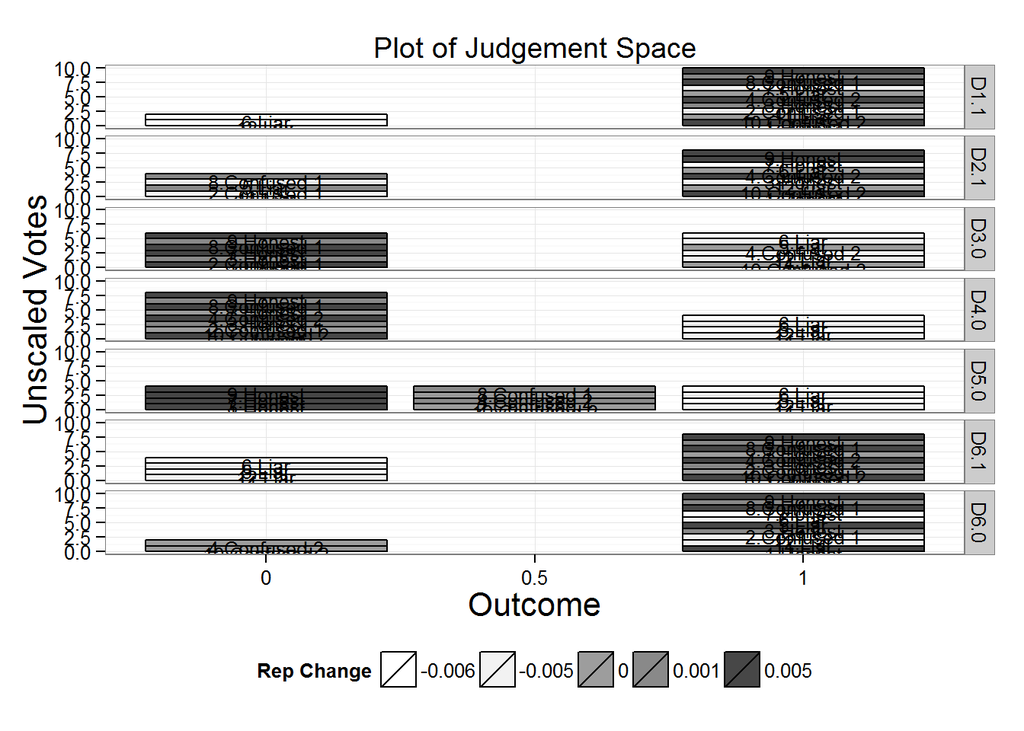

```r
PlotJ(M=Scenarios$Missing3)
```

```r
Factory(Scenarios$Missing4)
```

```
## $Original
##            D1.1 D2.1 D3.0 D4.0 D5.0 D6.1 D6.0
## Honest        1    1    0    0    0    1   NA
## Confused 1    1   NA   NA    0   NA    1   NA
## Honest        1    1    0    0    0    1   NA
## Confused 2    1    1    1    0   NA   NA    0
## Liar          0    0   NA   NA   NA   NA    1
## Liar         NA   NA   NA   NA    1    0    1
## Honest       NA   NA    0    0    0    1   NA
## Confused 1   NA   NA    0    0   NA    1   NA
## Honest        1    1    0    0    0    1   NA
## Confused 2    1    1    1    0   NA   NA    0
##
## $Filled
##            D1.1 D2.1 D3.0 D4.0 D5.0 D6.1 D6.0
## Honest        1    1    0    0    0    1  0.5
## Confused 1    1    1    0    0    0    1  0.5
## Honest        1    1    0    0    0    1  0.5
## Confused 2    1    1    1    0    0    1  0.0
## Liar          0    0    0    0    0    1  1.0
## Liar          1    1    0    0    1    0  1.0
## Honest        1    1    0    0    0    1  0.5
## Confused 1    1    1    0    0    0    1  0.5
## Honest        1    1    0    0    0    1  0.5
## Confused 2    1    1    1    0    0    1  0.0
##
## $Agents
##            OldRep      ThisRep SmoothRep NArow ParticipationR RelativePart
## Honest        0.1 1.111111e-01 0.1011111     1      0.8571429   0.13636364
## Confused 1    0.1 1.111111e-01 0.1011111     4      0.4285714   0.06818182
## Honest        0.1 1.111111e-01 0.1011111     1      0.8571429   0.13636364
## Confused 2    0.1 1.666667e-01 0.1066667     2      0.7142857   0.11363636
## Liar          0.1 2.848834e-17 0.0900000     4      0.4285714   0.06818182
## Liar          0.1 0.000000e+00 0.0900000     4      0.4285714   0.06818182
## Honest        0.1 1.111111e-01 0.1011111     3      0.5714286   0.09090909
## Confused 1    0.1 1.111111e-01 0.1011111     4      0.4285714   0.06818182
## Honest        0.1 1.111111e-01 0.1011111     1      0.8571429   0.13636364
## Confused 2    0.1 1.666667e-01 0.1066667     2      0.7142857   0.11363636
##              RowBonus
## Honest     0.11401465
```

[output cut: 20 more lines]

```
##                             D6.1       D6.0
## First Loading         -0.2886751 0.57735027
## DecisionOutcomes.Raw   0.9100000 0.48333333
## Consensus Reward       0.1605127 0.04280339
## Certainty              0.9100000 0.60666667
## NAs Filled             3.0000000 6.00000000
## ParticipationC         0.6966667 0.39333333
## Author Bonus           0.1592216 0.05957846
## DecisionOutcome.Final  1.0000000 0.50000000
##
## $Participation
## [1] 0.6339683
##
## $Certainty
## [1] 0.8619048
```

```r
Factory(Scenarios$Missing5)
```

```
## $Original
##               D1.1 D2.1 D3.0 D4.0 D1.1 D2.1 D3.0 D4.0
## Honest     NA   NA   NA   NA   NA    1    1    0    0
## Confused 1  1   NA   NA   NA   NA   NA    0    0    0
## Honest      1    1   NA   NA   NA   NA   NA    0    0
## Confused 2  1    1    1   NA   NA   NA   NA   NA    0
## Liar        0    0    0    1   NA   NA   NA   NA   NA
## Liar       NA    0    0    1    1   NA   NA   NA   NA
## Honest     NA   NA    1    0    0    1   NA   NA   NA
## Confused 1 NA   NA   NA    0    0    1    0   NA   NA
## Honest     NA   NA   NA   NA    0    1    1    0   NA
## Confused 2 NA   NA   NA   NA   NA    1    1    1    0
## Liar        0   NA   NA   NA   NA   NA    0    1    1
## Liar        0    0   NA   NA   NA   NA   NA    1    1
##
## $Filled
##                D1.1 D2.1 D3.0 D4.0 D1.1 D2.1 D3.0 D4.0
## Honest     0.5  0.5  0.5  0.5    0    1  1.0  0.0    0
## Confused 1 1.0  0.5  0.5  0.5    0    1  0.0  0.0    0
## Honest     1.0  1.0  0.5  0.5    0    1  0.5  0.0    0
## Confused 2 1.0  1.0  1.0  0.5    0    1  0.5  0.5    0
## Liar       0.0  0.0  0.0  1.0    0    1  0.5  0.5    0
## Liar       0.5  0.0  0.0  1.0    1    1  0.5  0.5    0
## Honest     0.5  0.5  1.0  0.0    0    1  0.5  0.5    0
## Confused 1 0.5  0.5  0.5  0.0    0    1  0.0  0.5    0
## Honest     0.5  0.5  0.5  0.5    0    1  1.0  0.0    0
## Confused 2 0.5  0.5  0.5  0.5    0    1  1.0  1.0    0
## Liar       0.0  0.5  0.5  0.5    0    1  0.0  1.0    1
## Liar       0.0  0.0  0.5  0.5    0    1  0.5  1.0    1
##
## $Agents
##                OldRep    ThisRep  SmoothRep NArow ParticipationR
## Honest     0.08333333 0.11303563 0.08630356     5      0.4444444
## Confused 1 0.08333333 0.11926953 0.08692695     5      0.4444444
## Honest     0.08333333 0.12979763 0.08797976     5      0.4444444
## Confused 2 0.08333333 0.12425297 0.08742530     5      0.4444444
## Liar       0.08333333 0.04335275 0.07933527     5      0.4444444
## Liar       0.08333333 0.05755747 0.08075575     5      0.4444444
## Honest     0.08333333 0.10833464 0.08583346     5      0.4444444
## Confused 1 0.08333333 0.09825913 0.08482591     5      0.4444444
```

[output cut: 37 more lines]

```
##                            D4.0
## First Loading         0.4727348
## DecisionOutcomes.Raw  0.1511909
## Consensus Reward      0.2018738
## Certainty             0.8488091
## NAs Filled            5.0000000
## ParticipationC        0.5829460
## Author Bonus          0.1706864
## DecisionOutcome.Final 0.0000000
##
## $Participation
## [1] 0.4444444
##
## $Certainty
## [1] 0.679456
```

```r
# Liars are still punished, even though outcomes quickly collapse toward (.5).


Factory(Scenarios$Riven)
```

```
## $Original
##            D1.1 D2.1 D3.0 D4.0 D1.1 D2.1 D3.0 D4.0 D1.1 D2.1 D3.0 D4.0
## Honest        1    1    0    0   NA   NA   NA   NA   NA   NA   NA   NA
## Confused 1    1    0    0    0   NA   NA   NA   NA   NA   NA   NA   NA
## Honest        1    1    0    0   NA   NA   NA   NA   NA   NA   NA   NA
## Confused 2    1    1    1    0   NA   NA   NA   NA   NA   NA   NA   NA
## Liar          0    0    1    1   NA   NA   NA   NA   NA   NA   NA   NA
## Liar          0    0    1    1   NA   NA   NA   NA   NA   NA   NA   NA
## Honest       NA   NA   NA   NA    1    1    0    0   NA   NA   NA   NA
## Confused 1   NA   NA   NA   NA    1    0    0    0   NA   NA   NA   NA
## Honest       NA   NA   NA   NA    1    1    0    0   NA   NA   NA   NA
## Confused 2   NA   NA   NA   NA    1    1    1    0   NA   NA   NA   NA
## Liar         NA   NA   NA   NA    0    0    1    1   NA   NA   NA   NA
## Liar         NA   NA   NA   NA    0    0    1    1   NA   NA   NA   NA
## Honest       NA   NA   NA   NA   NA   NA   NA   NA    1    1    0    0
## Confused 1   NA   NA   NA   NA   NA   NA   NA   NA    1    0    0    0
## Honest       NA   NA   NA   NA   NA   NA   NA   NA    1    1    0    0
## Confused 2   NA   NA   NA   NA   NA   NA   NA   NA    1    1    1    0
## Liar         NA   NA   NA   NA   NA   NA   NA   NA    0    0    1    1
## Liar         NA   NA   NA   NA   NA   NA   NA   NA    0    0    1    1
##
## $Filled
##            D1.1 D2.1 D3.0 D4.0 D1.1 D2.1 D3.0 D4.0 D1.1 D2.1 D3.0 D4.0
## Honest        1  1.0  0.0    0    1  0.5  0.5    0    1  0.5  0.5    0
## Confused 1    1  0.0  0.0    0    1  0.5  0.5    0    1  0.5  0.5    0
## Honest        1  1.0  0.0    0    1  0.5  0.5    0    1  0.5  0.5    0
## Confused 2    1  1.0  1.0    0    1  0.5  0.5    0    1  0.5  0.5    0
## Liar          0  0.0  1.0    1    1  0.5  0.5    0    1  0.5  0.5    0
## Liar          0  0.0  1.0    1    1  0.5  0.5    0    1  0.5  0.5    0
## Honest        1  0.5  0.5    0    1  1.0  0.0    0    1  0.5  0.5    0
## Confused 1    1  0.5  0.5    0    1  0.0  0.0    0    1  0.5  0.5    0
## Honest        1  0.5  0.5    0    1  1.0  0.0    0    1  0.5  0.5    0
## Confused 2    1  0.5  0.5    0    1  1.0  1.0    0    1  0.5  0.5    0
## Liar          1  0.5  0.5    0    0  0.0  1.0    1    1  0.5  0.5    0
## Liar          1  0.5  0.5    0    0  0.0  1.0    1    1  0.5  0.5    0
## Honest        1  0.5  0.5    0    1  0.5  0.5    0    1  1.0  0.0    0
## Confused 1    1  0.5  0.5    0    1  0.5  0.5    0    1  0.0  0.0    0
## Honest        1  0.5  0.5    0    1  0.5  0.5    0    1  1.0  0.0    0
## Confused 2    1  0.5  0.5    0    1  0.5  0.5    0    1  1.0  1.0    0
## Liar          1  0.5  0.5    0    1  0.5  0.5    0    0  0.0  1.0    1
```

[output cut: 70 more lines]

```
##                              D4.0
## First Loading          0.42532540
## DecisionOutcomes.Raw   0.10000000
## Consensus Reward       0.13485810
## Certainty              0.90000000
## NAs Filled            12.00000000
## ParticipationC         0.32526894
## Author Bonus           0.09916419
## DecisionOutcome.Final  0.00000000
##
## $Participation
## [1] 0.3333333
##
## $Certainty
## [1] 0.7783623
```

```r
Factory(Scenarios$Riven2)
```

```
## $Original
##            D1.1 D2.1 D3.0 D4.0 D1.1 D2.1 D3.0 D4.0 D1.1 D2.1 D3.0 D4.0
## Honest        1    1    0    0   NA   NA   NA   NA   NA   NA   NA   NA
## Confused 1    1    0    0    0   NA   NA   NA   NA   NA   NA   NA   NA
## Honest        1    1    0    0   NA   NA   NA   NA   NA   NA   NA   NA
## Confused 2    1    1    1    0   NA   NA   NA   NA   NA   NA   NA   NA
## Liar          0    0    1    1   NA   NA   NA   NA   NA   NA   NA   NA
## Liar          0    0    1    1   NA   NA   NA   NA   NA   NA   NA   NA
## Honest        1   NA   NA   NA    1    1    0    0   NA   NA   NA   NA
## Confused 1   NA   NA   NA   NA    1    0    0    0   NA   NA   NA   NA
## Honest       NA   NA   NA   NA    1    1    0    0   NA   NA   NA   NA
## Confused 2   NA   NA   NA   NA    1    1    1    0   NA   NA   NA   NA
## Liar         NA   NA   NA   NA    0    0    1    1   NA   NA   NA   NA
## Liar         NA   NA   NA   NA    0    0    1    1   NA   NA   NA   NA
## Honest       NA   NA   NA   NA   NA   NA   NA   NA    1    1    0    0
## Confused 1   NA   NA   NA   NA   NA   NA   NA   NA    1    0    0    0
## Honest       NA   NA   NA   NA   NA   NA   NA   NA    1    1    0    0
## Confused 2   NA   NA   NA   NA   NA   NA   NA   NA    1    1    1    0
## Liar         NA   NA   NA   NA   NA   NA   NA   NA    0    0    1    1
## Liar         NA   NA   NA   NA   NA   NA   NA   NA    0    0    1    1
##
## $Filled
##            D1.1 D2.1 D3.0 D4.0 D1.1 D2.1 D3.0 D4.0 D1.1 D2.1 D3.0 D4.0
## Honest        1  1.0  0.0    0    1  0.5  0.5    0    1  0.5  0.5    0
## Confused 1    1  0.0  0.0    0    1  0.5  0.5    0    1  0.5  0.5    0
## Honest        1  1.0  0.0    0    1  0.5  0.5    0    1  0.5  0.5    0
## Confused 2    1  1.0  1.0    0    1  0.5  0.5    0    1  0.5  0.5    0
## Liar          0  0.0  1.0    1    1  0.5  0.5    0    1  0.5  0.5    0
## Liar          0  0.0  1.0    1    1  0.5  0.5    0    1  0.5  0.5    0
## Honest        1  0.5  0.5    0    1  1.0  0.0    0    1  0.5  0.5    0
## Confused 1    1  0.5  0.5    0    1  0.0  0.0    0    1  0.5  0.5    0
## Honest        1  0.5  0.5    0    1  1.0  0.0    0    1  0.5  0.5    0
## Confused 2    1  0.5  0.5    0    1  1.0  1.0    0    1  0.5  0.5    0
## Liar          1  0.5  0.5    0    0  0.0  1.0    1    1  0.5  0.5    0
## Liar          1  0.5  0.5    0    0  0.0  1.0    1    1  0.5  0.5    0
## Honest        1  0.5  0.5    0    1  0.5  0.5    0    1  1.0  0.0    0
## Confused 1    1  0.5  0.5    0    1  0.5  0.5    0    1  0.0  0.0    0
## Honest        1  0.5  0.5    0    1  0.5  0.5    0    1  1.0  0.0    0
## Confused 2    1  0.5  0.5    0    1  0.5  0.5    0    1  1.0  1.0    0
## Liar          1  0.5  0.5    0    1  0.5  0.5    0    0  0.0  1.0    1
```

[output cut: 70 more lines]

```
##                              D4.0
## First Loading          0.42532540
## DecisionOutcomes.Raw   0.10000000
## Consensus Reward       0.13485810
## Certainty              0.90000000
## NAs Filled            12.00000000
## ParticipationC         0.32526894
## Author Bonus           0.09868313
## DecisionOutcome.Final  0.00000000
##
## $Participation
## [1] 0.3378797
##
## $Certainty
## [1] 0.7783623
```

## Scaled Claims

```r
#HoR party seats example

#add a new row
MS <- cbind(M1,  rbind(233,
                       199,
                       233,
                       250,
                       435,
                       435))
colnames(MS) <- c( colnames(MS)[-5], "C5.233")

#build non-default scales
Scales <- matrix( c( rep(FALSE,ncol(MS)),
                     rep(0,ncol(MS)),
                     rep(1,ncol(MS))), 3, byrow=TRUE, dimnames=list(c("Scaled","Min","Max"),colnames(MS)) )
Scales["Scaled",5] <- 1
Scales["Max",5] <- 435



#DJIA example

MS2 <- cbind(MS,  rbind(16027.59,
                       NA,
                       16027.59,
                       NA,
                       8001,
                       19999))

Scales2 <- cbind(Scales,rbind(1,8000,20000))

colnames(MS2) <- c( colnames(MS2)[-6], "C6.1602759")
colnames(Scales2) <- colnames(MS2)


#Edit catch to choose most-likely values (modal)

Factory(MS2,Scales2)
```

```
## $Original
##            D1.1 D2.1 D3.0 D4.0 C5.233 C6.1602759
## Honest        1    1    0    0    233   16027.59
## Confused 1    1    0    0    0    199         NA
## Honest        1    1    0    0    233   16027.59
## Confused 2    1    1    1    0    250         NA
## Liar          0    0    1    1    435    8001.00
## Liar          0    0    1    1    435   19999.00
##
## $Filled
##            D1.1 D2.1 D3.0 D4.0    C5.233   C6.1602759
## Honest        1    1    0    0 0.5356322 6.689658e-01
## Confused 1    1    0    0    0 0.4574713 6.689658e-01
## Honest        1    1    0    0 0.5356322 6.689658e-01
## Confused 2    1    1    1    0 0.5747126 6.689658e-01
## Liar          0    0    1    1 1.0000000 8.333333e-05
## Liar          0    0    1    1 1.0000000 9.999167e-01
##
## $Agents
##               OldRep    ThisRep SmoothRep NArow ParticipationR
## Honest     0.1666667 0.26193863 0.1761939     0      1.0000000
## Confused 1 0.1666667 0.23310999 0.1733110     1      0.8333333
## Honest     0.1666667 0.26193863 0.1761939     0      1.0000000
## Confused 2 0.1666667 0.22928252 0.1729283     1      0.8333333
## Liar       0.1666667 0.00000000 0.1500000     0      1.0000000
## Liar       0.1666667 0.01373022 0.1513730     0      1.0000000
##            RelativePart  RowBonus
## Honest        0.1764706 0.1762098
## Confused 1    0.1470588 0.1717961
## Honest        0.1764706 0.1762098
## Confused 2    0.1470588 0.1714354
## Liar          0.1764706 0.1515275
## Liar          0.1764706 0.1528213
##
## $Decisions
##                             D1.1        D2.1       D3.0      D4.0
## First Loading         -0.5223889 -0.43411264 0.44195128 0.5223889
## DecisionOutcomes.Raw   0.6986270  0.52531598 0.47430127 0.3013730
## Consensus Reward       0.5000000  0.00000000 0.00000000 0.5000000
## Certainty              0.6986270  0.00000000 0.00000000 0.6986270
## NAs Filled             0.0000000  0.00000000 0.00000000 0.0000000
## ParticipationC         1.0000000  1.00000000 1.00000000 1.0000000
## Author Bonus           0.4813535  0.01020675 0.01020675 0.4813535
## DecisionOutcome.Final  1.0000000  0.50000000 0.50000000 0.0000000
##                             C5.233    C6.1602759
## First Loading           0.24633679 -9.880889e-02
## DecisionOutcomes.Raw    0.53563218  6.689658e-01
## Consensus Reward        0.00000000  0.000000e+00
## Certainty               0.00000000  0.000000e+00
## NAs Filled              0.00000000  2.000000e+00
## ParticipationC          1.00000000  6.537607e-01
## Author Bonus            0.01020675  6.672775e-03
## DecisionOutcome.Final 233.00000000  1.602759e+04
##
## $Participation
## [1] 0.9422935
##
## $Certainty
## [1] 0.2328757
```

```r
# !!! Must FillNa with .5 FIRST, then average in, to prevent monopoly voting on brand-new contracts. (Actually, if it will eventually be ruled .5).

#Voting Across Time
#Later Votes should count more
#! ...simple change = ConoutFinal becomes exponentially smoothed result of previous chains.
#! require X number of chains (blocks) before the outcome is officially determined (two weeks?)

# Will need:
# 1] Percent Voted
# 2] Time Dimension of blocks.

#
# Possible solutions:
#   1 - sequential filling of NAs (sequential removal of columns) - pre-processing replace with average?
#   2 - what about the 'expert factor' idea? what happened to that?
#   3 - Completely replace FillNa with Reputations (lots of positives here)

#TO-DO
#Cascading reputation .6,.5,.3.,2., etc =   dexp(nrow(Mg))

#Mysterious behavior - loading only on first factor
#solutions
# 1- ignore. incentives will encourage filling out of contracts on 'obvious' events
# 2 - use later factors. Unknown what behavior could result from this
```

## Additive Reputation

Is reputation completely additive? - Yes, now.

```r
Mar1 <- M1
r1 <- rep(1/6,6)

Mar2 <- M1[-6,]
r2 <- c(1/6, 1/6, 1/6, 1/6, 2/6)

Mar3 <- M1[c(1,2,4,5),]
r3 <- c( 2/6, 1/6, 1/6, 2/6)

Mar4 <- M1[c(1,2,4,5,6),]
r4 <- c( 2/6, 1/6, 1/6, 1/6, 1/6)

Factory(Mar1,Rep=r1)$Agents
```

```
##               OldRep   ThisRep SmoothRep NArow ParticipationR RelativePart
## Honest     0.1666667 0.2673086 0.1767309     0              1    0.1666667
## Confused 1 0.1666667 0.2326914 0.1732691     0              1    0.1666667
## Honest     0.1666667 0.2673086 0.1767309     0              1    0.1666667
## Confused 2 0.1666667 0.2326914 0.1732691     0              1    0.1666667
## Liar       0.1666667 0.0000000 0.1500000     0              1    0.1666667
## Liar       0.1666667 0.0000000 0.1500000     0              1    0.1666667
##             RowBonus
## Honest     0.1767309
## Confused 1 0.1732691
## Honest     0.1767309
## Confused 2 0.1732691
## Liar       0.1500000
## Liar       0.1500000
```

```r
Factory(Mar2,Rep=r2)$Agents
```

```
##               OldRep   ThisRep SmoothRep NArow ParticipationR RelativePart
## Honest     0.1666667 0.2673086 0.1767309     0              1          0.2
## Confused 1 0.1666667 0.2326914 0.1732691     0              1          0.2
## Honest     0.1666667 0.2673086 0.1767309     0              1          0.2
## Confused 2 0.1666667 0.2326914 0.1732691     0              1          0.2
## Liar       0.3333333 0.0000000 0.3000000     0              1          0.2
##             RowBonus
## Honest     0.1767309
## Confused 1 0.1732691
## Honest     0.1767309
## Confused 2 0.1732691
## Liar       0.3000000
```

```r
Factory(Mar3,Rep=r3)$Agents
```

```
##               OldRep   ThisRep SmoothRep NArow ParticipationR RelativePart
## Honest     0.3333333 0.5346172 0.3534617     0              1         0.25
## Confused 1 0.1666667 0.2326914 0.1732691     0              1         0.25
## Confused 2 0.1666667 0.2326914 0.1732691     0              1         0.25
## Liar       0.3333333 0.0000000 0.3000000     0              1         0.25
##             RowBonus
## Honest     0.3534617
## Confused 1 0.1732691
## Confused 2 0.1732691
## Liar       0.3000000
```

```r
Factory(Mar4,Rep=r4)$Agents
```

```
##               OldRep   ThisRep SmoothRep NArow ParticipationR RelativePart
## Honest     0.3333333 0.5346172 0.3534617     0              1          0.2
## Confused 1 0.1666667 0.2326914 0.1732691     0              1          0.2
## Confused 2 0.1666667 0.2326914 0.1732691     0              1          0.2
## Liar       0.1666667 0.0000000 0.1500000     0              1          0.2
## Liar       0.1666667 0.0000000 0.1500000     0              1          0.2
##             RowBonus
## Honest     0.3534617
## Confused 1 0.1732691
## Confused 2 0.1732691
## Liar       0.1500000
## Liar       0.1500000
```

```r
#Is reputation additive? Yes (excluding NA-born effects, we could correct with Rep/mean(Rep) but NA is not part of equilibrium so it shouldnt matter).
```

```r
Factory(Mg)$Agents[,c("OldRep","ThisRep","SmoothRep")]
```

```
##                OldRep    ThisRep  SmoothRep
## Honest     0.05555556 0.05965188 0.05596519
## Confused 1 0.05555556 0.05965188 0.05596519
## Honest     0.05555556 0.05965188 0.05596519
## Confused 2 0.05555556 0.05965188 0.05596519
## Liar       0.05555556 0.05965188 0.05596519
## Liar       0.05555556 0.05965188 0.05596519
## Honest     0.05555556 0.04556998 0.05455700
## Confused 1 0.05555556 0.05965188 0.05596519
## Honest     0.05555556 0.04556998 0.05455700
## Confused 2 0.05555556 0.05965188 0.05596519
## Liar       0.05555556 0.08947781 0.05894778
## Liar       0.05555556 0.08947781 0.05894778
## Honest     0.05555556 0.06669283 0.05666928
## Confused 1 0.05555556 0.05965188 0.05596519
## Honest     0.05555556 0.06669283 0.05666928
## Confused 2 0.05555556 0.05965188 0.05596519
## Liar       0.05555556 0.00000000 0.05000000
## Liar       0.05555556 0.00000000 0.05000000
```

```r
Factory(Mg2)$Agents[,c("OldRep","ThisRep","SmoothRep")]
```

```
##                OldRep    ThisRep  SmoothRep
## Honest     0.05555556 0.05965188 0.05596519
## Confused 1 0.05555556 0.05965188 0.05596519
## Honest     0.05555556 0.05965188 0.05596519
## Confused 2 0.05555556 0.05965188 0.05596519
## Liar       0.05555556 0.05965188 0.05596519
## Liar       0.05555556 0.05965188 0.05596519
## Honest     0.05555556 0.04556998 0.05455700
## Confused 1 0.05555556 0.05965188 0.05596519
## Honest     0.05555556 0.04556998 0.05455700
## Confused 2 0.05555556 0.05965188 0.05596519
## Liar       0.05555556 0.08947781 0.05894778
## Liar       0.05555556 0.08947781 0.05894778
## Honest     0.05555556 0.06669283 0.05666928
## Confused 1 0.05555556 0.05965188 0.05596519
## Honest     0.05555556 0.06669283 0.05666928
## Confused 2 0.05555556 0.05965188 0.05596519
## Liar       0.05555556 0.00000000 0.05000000
## Liar       0.05555556 0.00000000 0.05000000
```

```r
# True 1 of group 2 skyrockets ahead, as desired.

# upon reflection, I dont think this 'problem' is particularly bad.
```

```r
Mub1 <- matrix(c(1, 0, 1.0, 1,  0.4498141, 0, 0, 1, 1, 0.7488008,
                 0, 0, 0.5, NA, 0.4460967, 0, 0, 1, 0, 0.7488008,
                 1, 0, 1.0, 1,  0.4498141, 0, 0, 1, 1, NA), 3, byrow = TRUE)

Sc <- BinaryScales(Mub1)
Sc["Scaled",c(5,10)] <- 1

Factory(Mub1, Scales = Sc, Verbose = TRUE)
```

```
## [1] "Missing Values Detected. Beginning presolve using availiable values."
## [1] "****************************************************"
## [1] "Begin 'GetDecisionOutcomes'"
## [1] "** **"
## [1] "Column:"
## [1] 1
##           [,1]
## [1,] 0.3333333
## [2,] 0.3333333
## [3,] 0.3333333
## [1] 1 0 1
## [1] "Consensus:"
## [1] 0.6666667
## [1] "** **"
## [1] "Column:"
```

[output cut: 171 more lines]

```
## $Original
##      [,1] [,2] [,3] [,4]      [,5] [,6] [,7] [,8] [,9]     [,10]
## [1,]    1    0  1.0    1 0.4498141    0    0    1    1 0.7488008
## [2,]    0    0  0.5   NA 0.4460967    0    0    1    0 0.7488008
## [3,]    1    0  1.0    1 0.4498141    0    0    1    1        NA
##
## $Filled
##      [,1] [,2] [,3] [,4]      [,5] [,6] [,7] [,8] [,9]     [,10]
## [1,]    1    0  1.0    1 0.4498141    0    0    1    1 0.7488008
## [2,]    0    0  0.5    1 0.4460967    0    0    1    0 0.7488008
## [3,]    1    0  1.0    1 0.4498141    0    0    1    1 0.7488008
##
## $Agents
##         OldRep ThisRep SmoothRep NArow ParticipationR RelativePart
## [1,] 0.3333333     0.5      0.35     0            1.0    0.3571429
## [2,] 0.3333333     0.0      0.30     1            0.9    0.3214286
## [3,] 0.3333333     0.5      0.35     1            0.9    0.3214286
##       RowBonus
## [1,] 0.3504643
## [2,] 0.3013929
## [3,] 0.3481429
##
## $Decisions
##                              [,1]      [,2]        [,3]      [,4]
## First Loading         -0.66666462 0.0000000 -0.33333231 0.0000000
## DecisionOutcomes.Raw   0.70000000 0.0000000  0.85000000 1.0000000
## Consensus Reward       0.08171206 0.1167315  0.05447471 0.1167315
## Certainty              0.70000000 1.0000000  0.70000000 1.0000000
## NAs Filled             0.00000000 0.0000000  0.00000000 1.0000000
## ParticipationC         1.00000000 1.0000000  1.00000000 0.7000000
## Author Bonus           0.08335265 0.1160958  0.05788572 0.1140103
## DecisionOutcome.Final  1.00000000 0.0000000  1.00000000 1.0000000
##                               [,5]      [,6]      [,7]      [,8]
## First Loading         -0.002478259 0.0000000 0.0000000 0.0000000
## DecisionOutcomes.Raw   0.449814100 0.0000000 0.0000000 1.0000000
## Consensus Reward       0.081712062 0.1167315 0.1167315 0.1167315
## Certainty              0.700000000 1.0000000 1.0000000 1.0000000
## NAs Filled             0.000000000 0.0000000 0.0000000 0.0000000
## ParticipationC         1.000000000 1.0000000 1.0000000 1.0000000
## Author Bonus           0.083352650 0.1160958 0.1160958 0.1160958
## DecisionOutcome.Final  0.449814100 0.0000000 0.0000000 1.0000000
##                              [,9]     [,10]
## First Loading         -0.66666462 0.0000000
## DecisionOutcomes.Raw   0.70000000 0.7488008
## Consensus Reward       0.08171206 0.1167315
## Certainty              0.70000000 1.0000000
## NAs Filled             0.00000000 1.0000000
## ParticipationC         1.00000000 0.6500000
## Author Bonus           0.08335265 0.1136627
## DecisionOutcome.Final  1.00000000 0.7488008
##
## $Participation
## [1] 0.935
##
## $Certainty
## [1] 0.88
```